# Data_Harvesting_Lyrics_ES_DE_TR

## 0.1 Introduction / Purpose of Study

The purpose of this project is to showcase data harvesting skills and perform a text mining assignment to reveal violent language use in rap-hiphop songs across German, Turkish and Spanish on the basis of gender.

As the reader is soon to witness, this project will gradually drift apart from the gender violence focus and employ a general sentiment analysis approach. But worry not! This is only because all three languages have done very well and used violent language in the gender context extremely rarely. That is why we asked the following question: Then what do they sing about?

To not spoil all the fun, we will move onto the scraping section.

## 0.2 Libraries

```r
library(rvest)
library(stringdist)
library(httr)
library(jsonlite)
library(dplyr)
library(purrr)
library(tibble)
library(tidyr)
library(stringr)
library(stopwords)
library(widyr)
library(ggplot2)
library(tidytext)
library(quanteda)
library(wordcloud2)
```

## 0.3 Top 5 German Hip/ Hop Rap Artists & Their Top Songs on Spotify

Authentication: Get Spotify API Token

```r
get_spotify_token <- function(client_id, client_secret) {
  auth_url <- "https://accounts.spotify.com/api/token"

  response <- POST(
    auth_url,
    body = list(
      grant_type = "client_credentials",
      client_id = SPOTIFY_CLIENT_ID,
      client_secret = SPOTIFY_CLIENT_SECRET
    ),
    encode = "form"
  )


  if (http_status(response)$category != "Success") {
    stop("Failed to authenticate. Check your client ID and secret.")
  }


  token_data <- content(response, as = "parsed", type = "application/json")


  if (!"access_token" %in% names(token_data)) {
    stop("Error: Could not retrieve access token.")
  }

  return(token_data$access_token)
}

access_token <- get_spotify_token(SPOTIFY_CLIENT_ID, SPOTIFY_CLIENT_SECRET)
```

Search for Hip-Hop/Rap Artists from Germany

```r
search_artists <- function(query, access_token, limit = 50) {
  Sys.sleep(0.5)

  response <- GET(
    "https://api.spotify.com/v1/search",
    query = list(q = query, type = "artist", limit = limit),
    add_headers(Authorization = paste("Bearer", access_token))
  )


  if (http_status(response)$category != "Success") {
    message("API request failed for query: ", query)
    return(NULL)
  }

  data <- content(response, as = "parsed", type = "application/json")


  if (!"artists" %in% names(data) || length(data$artists$items) == 0) {
    message("No artists found for query: ", query)
    return(NULL)
  }


  tibble(
    id = map_chr(data$artists$items, "id", .default = NA),
    name = map_chr(data$artists$items, "name", .default = NA),
    popularity = map_dbl(data$artists$items, "popularity", .default = 0)
  )
}

search_terms_german <- c("Deutschrap", "Rap Germany", "Deutscher Rapper", "Trap Germany", "Drill Germany",
                         "Hip Hop Germany")


all_artists_german <- map_df(search_terms_german, search_artists, access_token = access_token) %>%
  distinct(id, .keep_all = TRUE) %>%
  arrange(desc(popularity))

top_artists_german <- head(all_artists_german, 7)
```

Fetch Detailed Artist Metadata

```r
get_artist_details_german <- function(artist_ids, access_token) {
  Sys.sleep(0.5)

  response <- GET(
    "https://api.spotify.com/v1/artists",
    query = list(ids = paste(artist_ids, collapse = ",")),
    add_headers(Authorization = paste("Bearer", access_token))
  )


  data <- content(response, as = "parsed")$artists


  tibble(
    id = map_chr(data, "id"),
    followers = map_dbl(data, ~ .x$followers$total %||% 0)
  )
}

artist_details_german <- get_artist_details_german(top_artists_german$id, access_token)

top_artists_german <- left_join(top_artists_german, artist_details_german, by = "id")
```

Retrieve Top Songs for Each Artist

```r
get_top_tracks <- function(artist_id, access_token) {
  Sys.sleep(0.5)

  response <- GET(
    paste0("https://api.spotify.com/v1/artists/", artist_id, "/top-tracks"),
    query = list(market = "DE"),
    add_headers(Authorization = paste("Bearer", access_token))
  )

  tracks_data <- content(response, as = "parsed")$tracks

  if (length(tracks_data) == 0) {
    return(tibble(track_name = NA_character_, track_popularity = NA_real_))
  }

  tibble(
    track_name = map_chr(tracks_data[1:5], "name", .default = NA),
    track_popularity = map_dbl(tracks_data[1:5], "popularity", .default = NA)
  )
}

top_artists_german <- top_artists_german %>%
  mutate(top_tracks = map(id, ~ get_top_tracks(.x, access_token)))
```

Clean and Format the Final Results

```r
top_artists_german_tracks <- top_artists_german %>%
  select(artist_name = name, artist_popularity = popularity,
         followers, top_tracks) %>%
  unnest(cols = top_tracks)


top_artists_german_tracks <- top_artists_german_tracks %>%
  filter(!artist_name %in% c("Morad", "Rvfv"))


print(top_artists_german_tracks)
```

```
# A tibble: 25 × 5
   artist_name artist_popularity followers track_name         track_popularity
   <chr>                   <dbl>     <dbl> <chr>                         <dbl>
 1 Bonez MC                   76   2323623 Toyota (2016)                    68
 2 Bonez MC                   76   2323623 Ohne mein Team                   67
 3 Bonez MC                   76   2323623 Blaues Licht                     65
 4 Bonez MC                   76   2323623 Extasy                           62
 5 Bonez MC                   76   2323623 Palmen aus Plastik               65
 6 Luciano                    75   2395215 Butcher                          71
 7 Luciano                    75   2395215 PLAYBOYBUNNIES                   71
 8 Luciano                    75   2395215 Gesegnet                         70
 9 Luciano                    75   2395215 Cold as Ice                      69
10 Luciano                    75   2395215 Starboy                          68
# ℹ 15 more rows
```

## 0.4 Top 5 Turkish Hip/ Hop Rap Artists & Their Top Songs on Spotify

Authentication: Get Spotify API Token

```r
get_spotify_token <- function(client_id, client_secret) {
  auth_url <- "https://accounts.spotify.com/api/token"

  response <- POST(
    auth_url,
    body = list(
      grant_type = "client_credentials",
      client_id = SPOTIFY_CLIENT_ID,
      client_secret = SPOTIFY_CLIENT_SECRET
    ),
    encode = "form"
  )

  if (http_status(response)$category != "Success") {
    stop("Failed to authenticate. Check your client ID and secret.")
  }

  token_data <- content(response, as = "parsed", type = "application/json")

  if (!"access_token" %in% names(token_data)) {
    stop("Error: Could not retrieve access token.")
  }

  return(token_data$access_token)
}

access_token <- get_spotify_token(SPOTIFY_CLIENT_ID, SPOTIFY_CLIENT_SECRET)
```

Search for Hip-Hop/Rap Artists from Turkey

Authentication: Get Spotify API Token

```r
get_spotify_token <- function(client_id, client_secret) {
  auth_url <- "https://accounts.spotify.com/api/token"

  response <- POST(
    auth_url,
    body = list(
      grant_type = "client_credentials",
      client_id = SPOTIFY_CLIENT_ID,
      client_secret = SPOTIFY_CLIENT_SECRET
    ),
    encode = "form"
  )

  if (http_status(response)$category != "Success") {
    stop("Failed to authenticate. Check your client ID and secret.")
  }

  token_data <- content(response, as = "parsed", type = "application/json")

  if (!"access_token" %in% names(token_data)) {
    stop("Error: Could not retrieve access token.")
  }

  return(token_data$access_token)
}
access_token <- get_spotify_token(client_id, client_secret)
```

Search for Hip-Hop/Rap Artists from Turkey

```r
search_artists <- function(query, access_token, limit = 50) {
  Sys.sleep(0.5)

  response <- GET(
    "https://api.spotify.com/v1/search",
    query = list(q = query, type = "artist", limit = limit),
    add_headers(Authorization = paste("Bearer", access_token))
  )

  if (http_status(response)$category != "Success") {
    message("API request failed for query: ", query)
    return(NULL)
  }

  data <- content(response, as = "parsed", type = "application/json")

  if (!"artists" %in% names(data) || length(data$artists$items) == 0) {
    message("No artists found for query: ", query)
    return(NULL)
  }


  tibble(
    id = map_chr(data$artists$items, "id", .default = NA),
    name = map_chr(data$artists$items, "name", .default = NA),
    popularity = map_dbl(data$artists$items, "popularity", .default = 0)
  )
}

search_terms <- c("hip hop Türkiye", "rap Türkiye", "trap Türkiye", "drill Türkiye",
                  "alternatif rap Türkiye", "gangsta rap Türkiye", "hip hop underground Türkiye", "old school hip hop Türkiye")

all_artists <- map_df(search_terms, search_artists, access_token = access_token) %>%
  distinct(id, .keep_all = TRUE) %>%
  arrange(desc(popularity))
top_artists <- head(all_artists, 5)
```

Fetch Detailed Artist Metadata

```r
get_artist_details <- function(artist_ids, access_token) {
  Sys.sleep(0.5)

  response <- GET(
    "https://api.spotify.com/v1/artists",
    query = list(ids = paste(artist_ids, collapse = ",")),
    add_headers(Authorization = paste("Bearer", access_token))
  )


  data <- content(response, as = "parsed")$artists

  tibble(
    id = map_chr(data, "id"),
    followers = map_dbl(data, ~ .x$followers$total %||% 0)
  )
}


artist_details <- get_artist_details(top_artists$id, access_token)

top_artists <- left_join(top_artists, artist_details, by = "id")
```

Retrieve Top 3 Songs for Each Artist

```r
get_top_tracks <- function(artist_id, access_token) {
  Sys.sleep(0.5)

  response <- GET(
    paste0("https://api.spotify.com/v1/artists/", artist_id, "/top-tracks"),
    query = list(market = "TR"),
    add_headers(Authorization = paste("Bearer", access_token))
  )

  tracks_data <- content(response, as = "parsed")$tracks

  if (length(tracks_data) == 0) {
    return(tibble(track_name = NA_character_, track_popularity = NA_real_))
  }

  tibble(
    track_name = map_chr(tracks_data[1:3], "name", .default = NA),
    track_popularity = map_dbl(tracks_data[1:3], "popularity", .default = NA)
  )
}

top_artists <- top_artists %>%
  mutate(top_tracks = map(id, ~ get_top_tracks(.x, access_token)))
```

Clean and Format the Final Results

```r
top_artists_tracks <- top_artists %>%
  select(artist_name = name, artist_popularity = popularity,
         followers, top_tracks) %>%
  unnest(cols = top_tracks)

print(top_artists_tracks)
```

```
# A tibble: 15 × 5
   artist_name artist_popularity followers track_name           track_popularity
   <chr>                   <dbl>     <dbl> <chr>                           <dbl>
 1 BLOK3                      76   3168778 SEVMEYİ DENEMEDİN                  80
 2 BLOK3                      76   3168778 UYUZ                               75
 3 BLOK3                      76   3168778 aklına ben gelicem                 75
 4 UZI                        73   5622660 NEON                               76
 5 UZI                        73   5622660 1 YIL                              67
 6 UZI                        73   5622660 ZOR                                66
 7 Lvbel C5                   72   3735731 HAVHAVHAV                          73
 8 Lvbel C5                   72   3735731 kAHpE                              71
 9 Lvbel C5                   72   3735731 Sezen Aksu                         68
10 Ezhel                      71   6520404 Geceler                            67
11 Ezhel                      71   6520404 İmkansızım                         66
12 Ezhel                      71   6520404 Kadehimi Boş Bırakma               59
13 cakal                      69   2501277 Damlarsın                          69
14 cakal                      69   2501277 DOYAMADIM                          68
15 cakal                      69   2501277 Diyardan Diyara                    68
```

## 0.5 Top 5 Spanish Artists Hip/ Hop Rap Artists & Their Top Songs on Spotify

Authentication: Get Spotify API Token

```r
get_spotify_token <- function(client_id, client_secret) {
  auth_url <- "https://accounts.spotify.com/api/token"

  response <- POST(
    auth_url,
    body = list(
      grant_type = "client_credentials",
      client_id = SPOTIFY_CLIENT_ID,
      client_secret = SPOTIFY_CLIENT_SECRET
    ),
    encode = "form"
  )

  if (http_status(response)$category != "Success") {
    stop("Failed to authenticate. Check your client ID and secret.")
  }

  token_data <- content(response, as = "parsed", type = "application/json")

  if (!"access_token" %in% names(token_data)) {
    stop("Error: Could not retrieve access token.")
  }

  return(token_data$access_token)
}

access_token <- get_spotify_token(SPOTIFY_CLIENT_ID, SPOTIFY_CLIENT_SECRET)
```

Search for Hip-Hop/Rap Artists from Spain

```r
search_artists_es <- function(query, access_token, limit = 50) {
  Sys.sleep(0.5)

  response <- GET(
    "https://api.spotify.com/v1/search",
    query = list(q = query, type = "artist", limit = limit),
    add_headers(Authorization = paste("Bearer", access_token))
  )

  if (http_status(response)$category != "Success") {
    message("API request failed for query: ", query)
    return(NULL)
  }

  data <- content(response, as = "parsed", type = "application/json")

  if (!"artists" %in% names(data) || length(data$artists$items) == 0) {
    message("No artists found for query: ", query)
    return(NULL)
  }

  tibble(
    id = map_chr(data$artists$items, "id", .default = NA),
    name = map_chr(data$artists$items, "name", .default = NA),
    popularity = map_dbl(data$artists$items, "popularity", .default = 0)
  )
}

search_terms_es <- c("hip hop España", "rap España", "trap España", "drill España",
                     "rap alternativo España", "rap consciente España",
                     "gangsta rap España", "hip hop underground España",
                     "latin trap España", "reggaeton España",
                     "música urbana España", "old school hip hop España",
                     "spanglish hip hop España")

all_artists_es <- map_df(search_terms_es, search_artists_es, access_token = access_token) %>%
  distinct(id, .keep_all = TRUE) %>%
  arrange(desc(popularity))

top_artists_es <- head(all_artists_es, 5)
```

Fetch Detailed Artist Metadata

```r
get_artist_details_es <- function(artist_ids, access_token) {
  Sys.sleep(0.5)

  response <- GET(
    "https://api.spotify.com/v1/artists",
    query = list(ids = paste(artist_ids, collapse = ",")),
    add_headers(Authorization = paste("Bearer", access_token))
  )

  data_es <- content(response, as = "parsed")$artists

  tibble(
    id = map_chr(data_es, "id"),
    followers = map_dbl(data_es, ~ .x$followers$total %||% 0)
  )
}

artist_details_es <- get_artist_details_es(top_artists_es$id, access_token)

top_artists_es <- left_join(top_artists_es, artist_details_es, by = "id")
```

Retrieve Top 3 Songs for Each Artist

```r
get_top_tracks_es <- function(artist_id, access_token, existing_songs = NULL) {
  Sys.sleep(0.5)

  response_es <- GET(
    paste0("https://api.spotify.com/v1/artists/", artist_id, "/top-tracks"),
    query = list(market = "ES"),
    add_headers(Authorization = paste("Bearer", access_token))
  )

  if (status_code(response_es) != 200) {
    message(paste("API request failed for artist ID:", artist_id, "Status:", status_code(response_es)))
    return(tibble(track_name_es = NA_character_, track_popularity_es = NA_real_))
  }

  parsed_response <- content(response_es, as = "parsed", type = "application/json")

  if (!"tracks" %in% names(parsed_response) || length(parsed_response$tracks) == 0) {
    message(paste("No tracks found for artist ID:", artist_id))
    return(tibble(track_name_es = NA_character_, track_popularity_es = NA_real_))
  }

  tracks_data_es <- parsed_response$tracks

  tracks_df_es <- tibble(
    track_name_es = map_chr(tracks_data_es, "name", .default = NA),
    track_popularity_es = map_dbl(tracks_data_es, "popularity", .default = NA)
  ) %>%
    arrange(desc(track_popularity_es))

  if (!is.null(existing_songs)) {
    tracks_df_es <- tracks_df_es %>% filter(!(track_name_es %in% existing_songs))
  }

  return(head(tracks_df_es, min(nrow(tracks_df_es), 3)))
}

selected_songs_es <- c()

top_artists_es <- top_artists_es %>%
  mutate(top_tracks_es = map(id, ~ {
    tracks <- get_top_tracks_es(.x, access_token, existing_songs = selected_songs_es)
    selected_songs_es <<- c(selected_songs_es, tracks$track_name_es)
    return(tracks)
  }))
```

Clean and Format the Final Results

```r
top_artists_tracks_es <- top_artists_es %>%
  select(artist_name = name, artist_popularity = popularity,
         followers, top_tracks_es) %>%
  unnest(cols = top_tracks_es)

print(top_artists_tracks_es)
```

```
# A tibble: 15 × 5
   artist_name artist_popularity followers track_name_es     track_popularity_es
   <chr>                   <dbl>     <dbl> <chr>                           <dbl>
 1 Morad                      81   4007114 Sigue                              77
 2 Morad                      81   4007114 Lo Que Tiene                       75
 3 Morad                      81   4007114 SE FUE                             75
 4 Beny Jr                    76   1756601 Luna llena                         73
 5 Beny Jr                    76   1756601 Triple Impacto                     68
 6 Beny Jr                    76   1756601 Eurovision (feat…                  66
 7 JC Reyes                   76   1176441 BADGYAL                            72
 8 JC Reyes                   76   1176441 STAR                               71
 9 JC Reyes                   76   1176441 FARDOS                             69
10 Rvfv                       74    856720 Desespero                          66
11 Rvfv                       74    856720 Corazón Puro                       64
12 Rvfv                       74    856720 Casanova                           64
13 SAIKO                      74   1633951 COSAS QUE NO TE …                  76
14 SAIKO                      74   1633951 Juguete                            71
15 SAIKO                      74   1633951 REINA                              70
```

## 0.6 Extracting Genius IDs for songs and their URLs

```r
get_genius_token <- function(client_id, client_secret) {
  response <- POST(
    "https://api.genius.com/oauth/token",
    body = list(
      grant_type = "client_credentials",
      client_id = GENIUS_CLIENT_ID,
      client_secret = GENIUS_CLIENT_SECRET
    ),
    encode = "form"
  )
  if (status_code(response) != 200) {
    stop("Oops! Can’t get a new card. Check your ID and secret.")
  }
  data <- content(response, as = "parsed", type = "application/json")
  return(data$access_token)
}

genius_access_token <- get_genius_token(GENIUS_CLIENT_ID, GENIUS_CLIENT_SECRET)

genius_base_url <- "https://api.genius.com"

genious_get_song_data <- function(artist, track, access_token) {
  Sys.sleep(1)

  query <- paste(artist, track, "German", sep = " ")
  search_url <- paste0(genius_base_url, "/search")

  response <- GET(
    search_url,
    query = list(q = query, access_token = access_token),
    add_headers("User-Agent" = "Mozilla/5.0")
  )

  if (status_code(response) != 200) {
    message(paste("Search failed for:", artist, "-", track, "Status:", status_code(response)))
    return(list(url = NA, id = NA))
  }

  data <- content(response, as = "parsed", type = "application/json")
  hits <- data$response$hits

  if (length(hits) == 0) {
    message(paste("No Genius match found for:", artist, "-", track))
    return(list(url = NA, id = NA))
  }

  similarity <- function(a, b) stringdist(tolower(a), tolower(b), method = "lv")

  best_match <- NULL
  best_score <- Inf

  for (hit in hits) {
    song <- hit$result
    song_artist <- song$primary_artist$name
    song_title <- song$title
    song_url <- song$url
    song_id <- song$id

    if (!grepl("-lyrics$", song_url)) next

    artist_similarity <- similarity(artist, song_artist)
    track_similarity <- similarity(track, song_title)
    total_score <- artist_similarity + track_similarity

    if (total_score < best_score) {
      best_score <- total_score
      best_match <- list(url = song_url, id = song_id)
    }

    if (artist_similarity == 0 && track_similarity == 0) {
      message(paste("Found exact match Genius URL:", song_url))
      return(list(url = song_url, id = song_id))
    }
  }

  if (!is.null(best_match)) {
    message(paste("Found best match Genius URL:", best_match$url))
    return(best_match)
  }

  message(paste("No suitable match found for:", artist, "-", track))
  return(list(url = NA, id = NA))
}

top_artists_german_tracks <- top_artists_german_tracks %>%
  mutate(
    genius_data = map2(artist_name, track_name, ~ genious_get_song_data(.x, .y, genius_access_token)),
    genius_url = map_chr(genius_data, "url"),
    genius_id = map_int(genius_data, "id")
  ) %>%
  drop_na()
```

```
Found best match Genius URL: https://genius.com/Oso-oso-freestyle-mixtape-2016-lyrics
```

```
Found best match Genius URL: https://genius.com/Bonez-mc-wenn-du-mich-kennst-lyrics
```

```
Found best match Genius URL: https://genius.com/Bonez-mc-and-raf-camora-alles-umsonst-lyrics
```

```
Found best match Genius URL: https://genius.com/Bonez-mc-raf-camora-lx-maxwell-187-and-sa4-letzte-nacht-lyrics
```

```
Found best match Genius URL: https://genius.com/Bonez-mc-and-raf-camora-intro-palmen-aus-plastik-lyrics
```

```
Found best match Genius URL: https://genius.com/Sole-deu-phonix-lyrics
```

```
No suitable match found for: Luciano - PLAYBOYBUNNIES
```

```
Found best match Genius URL: https://genius.com/Mucco-on-ma-way-lyrics
```

```
Found best match Genius URL: https://genius.com/Bastardo-locale-istinto-animale-lyrics
```

```
Found best match Genius URL: https://genius.com/Mucco-on-ma-way-lyrics
```

```
Found best match Genius URL: https://genius.com/Raf-camora-zenit-snippet-lyrics
```

```
Found best match Genius URL: https://genius.com/Riba-end-up-on-my-radar-lyrics
```

```
Found best match Genius URL: https://genius.com/Bonez-mc-and-raf-camora-alles-umsonst-lyrics
```

```
Found best match Genius URL: https://genius.com/Bonez-mc-and-raf-camora-intro-palmen-aus-plastik-lyrics
```

```
Found best match Genius URL: https://genius.com/Raf-camora-and-yung-hurn-wien-lyrics
```

```
Found exact match Genius URL: https://genius.com/Ufo361-private-lyrics
```

```
No suitable match found for: Ufo361 - RICK OWENS (feat. Ken Carson)
```

```
Found best match Genius URL: https://genius.com/Ufo361-blnffm-lyrics
```

```
Found best match Genius URL: https://genius.com/Rap-genius-deutschland-diskographie-2017-lyrics
```

```
No Genius match found for: Ufo361 - RED CUPS (feat. Paula Hartmann)
```

```
No suitable match found for: Gzuz - G Wagon
```

```
Found best match Genius URL: https://genius.com/Gzuz-alles-zu-seiner-zeit-lyrics
```

```
Found best match Genius URL: https://genius.com/Hector-el-father-ombe-no-lyrics
```

```
Found best match Genius URL: https://genius.com/Gzuz-kopfnusse-lyrics
```

```
Found best match Genius URL: https://genius.com/Gzuz-hinterher-lyrics
```

```r
print(top_artists_german_tracks %>% select(artist_name, track_name, genius_url, genius_id))
```

```
# A tibble: 21 × 4
   artist_name track_name         genius_url                           genius_id
   <chr>       <chr>              <chr>                                    <int>
 1 Bonez MC    Toyota (2016)      https://genius.com/Oso-oso-freestyl…   4157141
 2 Bonez MC    Ohne mein Team     https://genius.com/Bonez-mc-wenn-du…  10120798
 3 Bonez MC    Blaues Licht       https://genius.com/Bonez-mc-and-raf…   8174131
 4 Bonez MC    Extasy             https://genius.com/Bonez-mc-raf-cam…   3920005
 5 Bonez MC    Palmen aus Plastik https://genius.com/Bonez-mc-and-raf…   2853616
 6 Luciano     Butcher            https://genius.com/Sole-deu-phonix-…   2418581
 7 Luciano     Gesegnet           https://genius.com/Mucco-on-ma-way-…  10891103
 8 Luciano     Cold as Ice        https://genius.com/Bastardo-locale-…   2972915
 9 Luciano     Starboy            https://genius.com/Mucco-on-ma-way-…  10891103
10 RAF Camora  Ohne mein Team     https://genius.com/Raf-camora-zenit…   4813438
# ℹ 11 more rows
```

### 0.6.1 Scrape Genius for German Lyrics

Function to Scrape Lyrics from Genius

```r
get_genius_lyrics <- function(song_url) {
  if (is.na(song_url)) return(NA)

  Sys.sleep(1)

  tryCatch({
    page <- read_html(song_url)

    lyrics <- page %>%
      html_nodes("div.lyrics") %>%
      html_text(trim = TRUE)

    if (length(lyrics) == 0) {
      lyrics <- page %>%
        html_nodes("div[class^='Lyrics__Container']") %>%
        html_text(trim = TRUE) %>%
        paste(collapse = " ")
    }

    if (length(lyrics) == 0) {
      message(paste("Lyrics not found for:", song_url))
      return(NA)
    }

    return(lyrics)
  }, error = function(e) {
    message(paste("Error scraping lyrics for:", song_url))
    return(NA)
  })
}


top_artists_german_tracks <- top_artists_german_tracks %>%
  mutate(lyrics  = map_chr(genius_url , get_genius_lyrics ))
```

View and Save Final Dataset

```r
print(top_artists_german_tracks  %>% select(artist_name, track_name , genius_url , genius_id , lyrics ))
```

```
# A tibble: 21 × 5
   artist_name track_name         genius_url                    genius_id lyrics
   <chr>       <chr>              <chr>                             <int> <chr>
 1 Bonez MC    Toyota (2016)      https://genius.com/Oso-oso-f…   4157141 "MY S…
 2 Bonez MC    Ohne mein Team     https://genius.com/Bonez-mc-…  10120798 "[Son…
 3 Bonez MC    Blaues Licht       https://genius.com/Bonez-mc-…   8174131 "[Son…
 4 Bonez MC    Extasy             https://genius.com/Bonez-mc-…   3920005 "[Son…
 5 Bonez MC    Palmen aus Plastik https://genius.com/Bonez-mc-…   2853616 "[Son…
 6 Luciano     Butcher            https://genius.com/Sole-deu-…   2418581 "[Son…
 7 Luciano     Gesegnet           https://genius.com/Mucco-on-…  10891103 "[Son…
 8 Luciano     Cold as Ice        https://genius.com/Bastardo-…   2972915 "RIT.…
 9 Luciano     Starboy            https://genius.com/Mucco-on-…  10891103 "[Son…
10 RAF Camora  Ohne mein Team     https://genius.com/Raf-camor…   4813438 "[Son…
# ℹ 11 more rows
```

```r
top_artists_german_tracks_atomic <- top_artists_german_tracks  %>%
  select(artist_name, track_name , genius_url , genius_id , lyrics ) %>%
  mutate(across(everything(), as.character))
write.csv(top_artists_german_tracks_atomic, "german_artists_lyrics.csv", row.names = FALSE)
```

### 0.6.2 Scrape Genius for Turkish Lyrics

Function to Scrape Lyrics from Genius

```r
get_genius_token <- function(client_id, client_secret) {
  response <- POST(
    "https://api.genius.com/oauth/token",
    body = list(
      grant_type = "client_credentials",
      client_id = GENIUS_CLIENT_ID,
      client_secret = GENIUS_CLIENT_SECRET
    ),
    encode = "form"
  )
  if (status_code(response) != 200) {
    stop("Oops! Can’t get a new card. Check your ID and secret.")
  }
  data <- content(response, as = "parsed", type = "application/json")
  return(data$access_token)
}


genius_access_token <- get_genius_token(GENIUS_CLIENT_ID, GENIUS_CLIENT_SECRET)
genius_base_url <- "https://api.genius.com"


get_genius_song_url <- function(artist, track, access_token) {
  Sys.sleep(1)


  query <- paste(artist, track, "Türkiye", sep = " ")
  search_url <- paste0(genius_base_url, "/search")


  response <- GET(
    search_url,
    query = list(q = query, access_token = access_token),
    add_headers("User-Agent" = "Mozilla/5.0")
  )


  if (status_code(response) != 200) {
    message(paste("Search failed for:", artist, "-", track, "Status:", status_code(response)))
    return(NA)
  }


  data <- content(response, as = "parsed", type = "application/json")
  hits <- data$response$hits


  if (length(hits) == 0) {
    message(paste("No Genius match found for:", artist, "-", track))
    return(NA)
  }


  similarity <- function(a, b) stringdist(tolower(a), tolower(b), method = "lv")


  best_match <- NULL
  best_score <- Inf

  for (hit in hits) {
    song <- hit$result
    song_artist <- song$primary_artist$name
    song_title <- song$title
    song_url <- song$url


    if (!grepl("-lyrics$", song_url)) next


    artist_similarity <- similarity(artist, song_artist)
    track_similarity <- similarity(track, song_title)
    total_score <- artist_similarity + track_similarity


    if (total_score < best_score) {
      best_score <- total_score
      best_match <- song_url
    }


    if (artist_similarity == 0 && track_similarity == 0) {
      message(paste("Found exact match Genius URL:", song_url))
      return(song_url)
    }
  }


  if (!is.null(best_match)) {
    message(paste("Found best match Genius URL:", best_match))
    return(best_match)
  }

  message(paste("No suitable match found for:", artist, "-", track))
  return(NA)
}


top_artists_tracks <- top_artists_tracks %>%
  mutate(
    genius_url = map2_chr(artist_name, track_name, ~ get_genius_song_url(.x, .y, genius_access_token))
  )
```

```
Found exact match Genius URL: https://genius.com/Blok3-sevmeyi-denemedin-lyrics
```

```
Found exact match Genius URL: https://genius.com/Blok3-uyuz-lyrics
```

```
Found exact match Genius URL: https://genius.com/Blok3-aklna-ben-gelicem-lyrics
```

```
Found exact match Genius URL: https://genius.com/Uzi-neon-lyrics
```

```
Found exact match Genius URL: https://genius.com/Uzi-1-yil-lyrics
```

```
Found exact match Genius URL: https://genius.com/Uzi-zor-lyrics
```

```
Found exact match Genius URL: https://genius.com/Lvbel-c5-havhavhav-lyrics
```

```
Found exact match Genius URL: https://genius.com/Lvbel-c5-akdo-and-alizade-kahpe-lyrics
```

```
Found exact match Genius URL: https://genius.com/Lvbel-c5-sezen-aksu-lyrics
```

```
Found exact match Genius URL: https://genius.com/Ezhel-geceler-lyrics
```

```
Found exact match Genius URL: https://genius.com/Ezhel-imkanszm-lyrics
```

```
Found exact match Genius URL: https://genius.com/Ezhel-kadehimi-bos-brakma-lyrics
```

```
Found exact match Genius URL: https://genius.com/Cakal-damlarsn-lyrics
```

```
Found best match Genius URL: https://genius.com/Akdo-and-cakal-doyamadim-lyrics
```

```
Found exact match Genius URL: https://genius.com/Cakal-arem-ozguc-and-arman-aydin-diyardan-diyara-lyrics
```

```r
print(top_artists_tracks %>% select(artist_name, track_name, genius_url))
```

```
# A tibble: 15 × 3
   artist_name track_name           genius_url
   <chr>       <chr>                <chr>
 1 BLOK3       SEVMEYİ DENEMEDİN    https://genius.com/Blok3-sevmeyi-denemedin-…
 2 BLOK3       UYUZ                 https://genius.com/Blok3-uyuz-lyrics
 3 BLOK3       aklına ben gelicem   https://genius.com/Blok3-aklna-ben-gelicem-…
 4 UZI         NEON                 https://genius.com/Uzi-neon-lyrics
 5 UZI         1 YIL                https://genius.com/Uzi-1-yil-lyrics
 6 UZI         ZOR                  https://genius.com/Uzi-zor-lyrics
 7 Lvbel C5    HAVHAVHAV            https://genius.com/Lvbel-c5-havhavhav-lyrics
 8 Lvbel C5    kAHpE                https://genius.com/Lvbel-c5-akdo-and-alizad…
 9 Lvbel C5    Sezen Aksu           https://genius.com/Lvbel-c5-sezen-aksu-lyri…
10 Ezhel       Geceler              https://genius.com/Ezhel-geceler-lyrics
11 Ezhel       İmkansızım           https://genius.com/Ezhel-imkanszm-lyrics
12 Ezhel       Kadehimi Boş Bırakma https://genius.com/Ezhel-kadehimi-bos-brakm…
13 cakal       Damlarsın            https://genius.com/Cakal-damlarsn-lyrics
14 cakal       DOYAMADIM            https://genius.com/Akdo-and-cakal-doyamadim…
15 cakal       Diyardan Diyara      https://genius.com/Cakal-arem-ozguc-and-arm…
```

```r
genious_base_url <- "https://api.genius.com"

get_genius_song_url <- function(artist, track, access_token) {
  Sys.sleep(1)

  query <- paste(artist, track, "Türkiye", sep = " ")
  search_url <- paste0(genious_base_url, "/search")

  response <- GET(
    search_url,
    query = list(q = query, access_token = access_token),
    add_headers("User-Agent" = "Mozilla/5.0")
  )

  if (status_code(response) != 200) {
    message(paste("Search failed for:", artist, "-", track, "Status:", status_code(response)))
    return(list(url = NA, id = NA))
  }

  data <- content(response, as = "parsed", type = "application/json")
  hits <- data$response$hits

  if (length(hits) == 0) {
    message(paste("No Genius match found for:", artist, "-", track))
    return(list(url = NA, id = NA))
  }

  similarity <- function(a, b) stringdist(tolower(a), tolower(b), method = "lv")

  best_match <- NULL
  best_score <- Inf

  for (hit in hits) {
    song <- hit$result
    song_artist <- song$primary_artist$name
    song_title <- song$title
    song_url <- song$url
    song_id <- song$id

    if (!grepl("-lyrics$", song_url)) next

    artist_similarity <- similarity(artist, song_artist)
    track_similarity <- similarity(track, song_title)
    total_score <- artist_similarity + track_similarity

    if (total_score < best_score) {
      best_score <- total_score
      best_match <- list(url = song_url, id = song_id)
    }

    if (artist_similarity == 0 && track_similarity == 0) {
      message(paste("Found exact match Genius URL:", song_url))
      return(list(url = song_url, id = song_id))
    }
  }

  if (!is.null(best_match)) {
    message(paste("Found best match Genius URL:", best_match$url))
    return(best_match)
  }

  message(paste("No suitable match found for:", artist, "-", track))
  return(list(url = NA, id = NA))
}

top_artists_tracks <- top_artists_tracks %>%
  mutate(
    genius_data = map2(artist_name, track_name, ~ get_genius_song_url(.x, .y, genius_access_token)),
    genius_url = map_chr(genius_data, "url"),
    genius_id = map_int(genius_data, "id")
  )
```

```
Found exact match Genius URL: https://genius.com/Blok3-sevmeyi-denemedin-lyrics
```

```
Found exact match Genius URL: https://genius.com/Blok3-uyuz-lyrics
```

```
Found exact match Genius URL: https://genius.com/Blok3-aklna-ben-gelicem-lyrics
```

```
Found exact match Genius URL: https://genius.com/Uzi-neon-lyrics
```

```
Found exact match Genius URL: https://genius.com/Uzi-1-yil-lyrics
```

```
Found exact match Genius URL: https://genius.com/Uzi-zor-lyrics
```

```
Found exact match Genius URL: https://genius.com/Lvbel-c5-havhavhav-lyrics
```

```
Found exact match Genius URL: https://genius.com/Lvbel-c5-akdo-and-alizade-kahpe-lyrics
```

```
Found exact match Genius URL: https://genius.com/Lvbel-c5-sezen-aksu-lyrics
```

```
Found exact match Genius URL: https://genius.com/Ezhel-geceler-lyrics
```

```
Found exact match Genius URL: https://genius.com/Ezhel-imkanszm-lyrics
```

```
Found exact match Genius URL: https://genius.com/Ezhel-kadehimi-bos-brakma-lyrics
```

```
Found exact match Genius URL: https://genius.com/Cakal-damlarsn-lyrics
```

```
Found best match Genius URL: https://genius.com/Akdo-and-cakal-doyamadim-lyrics
```

```
Found exact match Genius URL: https://genius.com/Cakal-arem-ozguc-and-arman-aydin-diyardan-diyara-lyrics
```

```r
print(top_artists_tracks %>% select(artist_name, track_name, genius_url, genius_id))
```

```
# A tibble: 15 × 4
   artist_name track_name           genius_url                         genius_id
   <chr>       <chr>                <chr>                                  <int>
 1 BLOK3       SEVMEYİ DENEMEDİN    https://genius.com/Blok3-sevmeyi-…  10794664
 2 BLOK3       UYUZ                 https://genius.com/Blok3-uyuz-lyr…  10794687
 3 BLOK3       aklına ben gelicem   https://genius.com/Blok3-aklna-be…   9481561
 4 UZI         NEON                 https://genius.com/Uzi-neon-lyrics  10437611
 5 UZI         1 YIL                https://genius.com/Uzi-1-yil-lyri…  11185826
 6 UZI         ZOR                  https://genius.com/Uzi-zor-lyrics    7152842
 7 Lvbel C5    HAVHAVHAV            https://genius.com/Lvbel-c5-havha…  11376198
 8 Lvbel C5    kAHpE                https://genius.com/Lvbel-c5-akdo-…  11312238
 9 Lvbel C5    Sezen Aksu           https://genius.com/Lvbel-c5-sezen…  10153283
10 Ezhel       Geceler              https://genius.com/Ezhel-geceler-…   3104934
11 Ezhel       İmkansızım           https://genius.com/Ezhel-imkanszm…   3267725
12 Ezhel       Kadehimi Boş Bırakma https://genius.com/Ezhel-kadehimi…  10666532
13 cakal       Damlarsın            https://genius.com/Cakal-damlarsn…  10222633
14 cakal       DOYAMADIM            https://genius.com/Akdo-and-cakal…   9245312
15 cakal       Diyardan Diyara      https://genius.com/Cakal-arem-ozg…   8644063
```

```r
get_genius_lyrics <- function(song_url) {
  if (is.na(song_url)) return(NA)

  Sys.sleep(1)

  tryCatch({
    page <- read_html(song_url)

    lyrics <- page %>%
      html_nodes("div.lyrics") %>%
      html_text(trim = TRUE)

    if (length(lyrics) == 0) {
      lyrics <- page %>%
        html_nodes("div[class^='Lyrics__Container']") %>%
        html_text(trim = TRUE) %>%
        paste(collapse = " ")
    }

    if (length(lyrics) == 0) {
      message(paste("Lyrics not found for:", song_url))
      return(NA)
    }

    return(lyrics)
  }, error = function(e) {
    message(paste("Error scraping lyrics for:", song_url))
    return(NA)
  })
}

top_artists_tracks <- top_artists_tracks %>%
  mutate(lyrics = map_chr(genius_url, get_genius_lyrics))




print(top_artists_tracks %>% select(artist_name, track_name, genius_url, genius_id, lyrics))
```

```
# A tibble: 15 × 5
   artist_name track_name           genius_url                  genius_id lyrics
   <chr>       <chr>                <chr>                           <int> <chr>
 1 BLOK3       SEVMEYİ DENEMEDİN    https://genius.com/Blok3-s…  10794664 "[\"S…
 2 BLOK3       UYUZ                 https://genius.com/Blok3-u…  10794687 "[\"U…
 3 BLOK3       aklına ben gelicem   https://genius.com/Blok3-a…   9481561 "[\"a…
 4 UZI         NEON                 https://genius.com/Uzi-neo…  10437611 "[\"N…
 5 UZI         1 YIL                https://genius.com/Uzi-1-y…  11185826 "[\"1…
 6 UZI         ZOR                  https://genius.com/Uzi-zor…   7152842 "[\"Z…
 7 Lvbel C5    HAVHAVHAV            https://genius.com/Lvbel-c…  11376198 "[\"H…
 8 Lvbel C5    kAHpE                https://genius.com/Lvbel-c…  11312238 "[\"k…
 9 Lvbel C5    Sezen Aksu           https://genius.com/Lvbel-c…  10153283 "[\"S…
10 Ezhel       Geceler              https://genius.com/Ezhel-g…   3104934 "[''G…
11 Ezhel       İmkansızım           https://genius.com/Ezhel-i…   3267725 "[\"İ…
12 Ezhel       Kadehimi Boş Bırakma https://genius.com/Ezhel-k…  10666532 "[\"K…
13 cakal       Damlarsın            https://genius.com/Cakal-d…  10222633 "[\"D…
14 cakal       DOYAMADIM            https://genius.com/Akdo-an…   9245312 "[\"D…
15 cakal       Diyardan Diyara      https://genius.com/Cakal-a…   8644063 "[\"D…
```

```r
top_artists_tracks_tr_atomic <- top_artists_tracks %>%
  select(artist_name, track_name, genius_url, genius_id, lyrics) %>%
  mutate(across(everything(), as.character))
```

```r
write.csv(top_artists_tracks_tr_atomic, "top_artists_tracks_with_TR.csv", row.names = FALSE)
```

### 0.6.3 Scrape Genius for Spanish Lyrics

Set Up Genius API

```r
get_genius_token_es <- function(client_id, client_secret) {
  auth_url <- "https://api.genius.com/oauth/token"

  response <- POST(
    auth_url,
    body = list(
      grant_type = "client_credentials",
      client_id = GENIUS_CLIENT_ID,
      client_secret = GENIUS_CLIENT_SECRET
    ),
    encode = "form"
  )

  if (http_status(response)$category != "Success") {
    stop("Failed to authenticate with Genius API. Check your client ID and secret.")
  }

  token_data <- fromJSON(rawToChar(response$content))

  if (!"access_token" %in% names(token_data)) {
    stop("Error: Could not retrieve Genius access token.")
  }

  return(token_data$access_token)
}

genius_access_token_es <- get_genius_token_es(GENIUS_CLIENT_ID, GENIUS_CLIENT_SECRET)

genius_base_url_es <- "https://api.genius.com"
```

Function to Search for a Song on Genius

```r
get_genius_song_data_es <- function(artist, track, access_token) {
  Sys.sleep(1)

  query <- paste(artist, track, sep = " ")
  search_url <- paste0(genius_base_url_es, "/search")

  response <- GET(
    search_url,
    query = list(q = query, access_token = access_token),
    add_headers("User-Agent" = "Mozilla/5.0")
  )

  if (status_code(response) != 200) {
    message(paste("Search failed for:", artist, "-", track, "Status:", status_code(response)))
    return(list(url = NA, id = NA))
  }

  data_es <- content(response, as = "parsed", type = "application/json")
  hits_es <- data_es$response$hits

  if (length(hits_es) == 0) {
    message(paste("No Genius match found for:", artist, "-", track))
    return(list(url = NA, id = NA))
  }

  similarity <- function(a, b) stringdist(tolower(a), tolower(b), method = "lv")

  best_match <- NULL
  best_score <- Inf

  for (hit in hits_es) {
    song <- hit$result
    song_artist <- song$primary_artist$name
    song_title <- song$title
    song_url <- song$url
    song_id <- song$id

    if (!grepl("-lyrics$", song_url)) next

    artist_similarity <- similarity(artist, song_artist)
    track_similarity <- similarity(track, song_title)
    total_score <- artist_similarity + track_similarity

    if (total_score < best_score) {
      best_score <- total_score
      best_match <- list(url = song_url, id = song_id)
    }

    if (artist_similarity == 0 && track_similarity == 0) {
      message(paste("Found exact match Genius URL:", song_url))
      return(list(url = song_url, id = song_id))
    }
  }

  if (!is.null(best_match)) {
    message(paste("Found best match Genius URL:", best_match$url))
    return(best_match)
  }

  message(paste("No suitable match found for:", artist, "-", track))
  return(list(url = NA, id = NA))
}
```

Add Genius URLs & IDs to top_artists_tracks_es

```r
top_artists_tracks_es <- top_artists_tracks_es %>%
  mutate(
    genius_data_es = map2(artist_name, track_name_es, ~ get_genius_song_data_es(.x, .y, genius_access_token_es)),
    genius_url_es = map_chr(genius_data_es, "url"),
    genius_id_es = map_int(genius_data_es, "id")
  )
```

```
Found best match Genius URL: https://genius.com/Beny-jr-morad-and-k-y-b-sigue-lyrics
```

```
Found exact match Genius URL: https://genius.com/Morad-beny-jr-and-rvfv-lo-que-tiene-lyrics
```

```
Found best match Genius URL: https://genius.com/Moncho-chavea-and-morad-se-fue-lyrics
```

```
Found exact match Genius URL: https://genius.com/Beny-jr-luna-llena-lyrics
```

```
Found exact match Genius URL: https://genius.com/Beny-jr-and-julianno-sosa-triple-impacto-lyrics
```

```
Found best match Genius URL: https://genius.com/Genius-brasil-traducoes-central-cee-eurovision-ft-rondodasosa-baby-gang-a2-anti-morad-beny-jr-ashe-22-and-freeze-corleone-traducao-em-portugues-lyrics
```

```
Found best match Genius URL: https://genius.com/Saiko-jc-reyes-and-dei-v-badgyal-lyrics
```

```
Found exact match Genius URL: https://genius.com/Jc-reyes-star-lyrics
```

```
Found exact match Genius URL: https://genius.com/Jc-reyes-and-de-la-ghetto-fardos-lyrics
```

```
Found best match Genius URL: https://genius.com/Morad-and-rvfv-desespero-lyrics
```

```
Found exact match Genius URL: https://genius.com/Rvfv-rels-b-and-morad-corazon-puro-lyrics
```

```
Found best match Genius URL: https://genius.com/Rvfv-nioma-pr-jc-el-diamante-and-radu-esp-uhlala-lyrics
```

```
Found exact match Genius URL: https://genius.com/Saiko-cosas-que-no-te-dije-lyrics
```

```
Found best match Genius URL: https://genius.com/Yan-block-ntg-and-saiko-juguete-lyrics
```

```
Found best match Genius URL: https://genius.com/Mora-and-saiko-reina-lyrics
```

Function to Scrape Lyrics from Genius

```r
get_genius_lyrics_es <- function(song_url) {
  if (is.na(song_url)) return(NA)

  Sys.sleep(1)

  tryCatch({
    page <- read_html(song_url)

    lyrics <- page %>%
      html_nodes("div.lyrics") %>%
      html_text(trim = TRUE)

    if (length(lyrics) == 0) {
      lyrics <- page %>%
        html_nodes("div[class^='Lyrics__Container']") %>%
        html_text(trim = TRUE) %>%
        paste(collapse = " ")
    }

    if (length(lyrics) == 0) {
      message(paste("Lyrics not found for:", song_url))
      return(NA)
    }

    return(lyrics)
  }, error = function(e) {
    message(paste("Error scraping lyrics for:", song_url))
    return(NA)
  })
}
```

Scrape Lyrics for All Songs

```r
top_artists_tracks_es <- top_artists_tracks_es %>%
  mutate(lyrics_es = map_chr(genius_url_es, get_genius_lyrics_es))
```

View and Save Final Dataset

```r
print(top_artists_tracks_es %>% select(artist_name, track_name_es, genius_url_es, genius_id_es, lyrics_es))
```

```
# A tibble: 15 × 5
   artist_name track_name_es                genius_url_es genius_id_es lyrics_es
   <chr>       <chr>                        <chr>                <int> <chr>
 1 Morad       Sigue                        https://geni…      7854976 "[Letra …
 2 Morad       Lo Que Tiene                 https://geni…     10138750 "[Letra …
 3 Morad       SE FUE                       https://geni…     11242420 "[Letra …
 4 Beny Jr     Luna llena                   https://geni…     10057729 "[Letra …
 5 Beny Jr     Triple Impacto               https://geni…     11285433 "[Letra …
 6 Beny Jr     Eurovision (feat. Rondodaso… https://geni…     10642164 "[Letra …
 7 JC Reyes    BADGYAL                      https://geni…     10225362 "[Letra …
 8 JC Reyes    STAR                         https://geni…     11003105 "[Letra …
 9 JC Reyes    FARDOS                       https://geni…     10061979 "[Letra …
10 Rvfv        Desespero                    https://geni…      9101583 "[Letra …
11 Rvfv        Corazón Puro                 https://geni…     11373804 "[Letra …
12 Rvfv        Casanova                     https://geni…     10392654 "[Letra …
13 SAIKO       COSAS QUE NO TE DIJE         https://geni…      7276986 "[Letra …
14 SAIKO       Juguete                      https://geni…     11058875 "[Letra …
15 SAIKO       REINA                        https://geni…      9252407 "[Letra …
```

```r
top_artists_tracks_es_atomic <- top_artists_tracks_es %>%
  select(artist_name, track_name_es, genius_url_es, genius_id_es, lyrics_es) %>%
  mutate(across(everything(), as.character))

write.csv(top_artists_tracks_es_atomic, "spanish_artists_lyrics.csv", row.names = FALSE)
```

## 0.7 Cleaning Data

```r
turkish_lyrics <- read.csv("top_artists_tracks_with_TR.csv")
```

```r
german_lyrics <- read.csv("german_artists_lyrics.csv")
```

Cleaning lyrics:

```r
clean_lyrics_de <- function(lyrics) {
  if (is.na(lyrics)) return(NA)
  lyrics <- str_replace_all(lyrics, "\\[.*?\\]", "")
  lyrics <- str_replace_all(lyrics, "\\(.*?\\)", "")
  lyrics <- str_replace_all(lyrics, "[^A-Za-z0-9äöüÄÖÜß\\s\\n.,?!;:'\"-]", "")
  lyrics <- str_replace_all(lyrics, "(?<=[a-z0-9])(?=[A-ZÄÖÜ])", "\n")
  lyrics <- str_squish(lyrics)

  return(lyrics)
}
```

```r
german_lyrics <- german_lyrics %>%
  mutate(cleaned_lyrics = map_chr(lyrics, clean_lyrics_de))

print(german_lyrics %>% select(artist_name, track_name, cleaned_lyrics))
```

```
   artist_name              track_name
1     Bonez MC           Toyota (2016)
2     Bonez MC          Ohne mein Team
3     Bonez MC            Blaues Licht
4     Bonez MC                  Extasy
5     Bonez MC      Palmen aus Plastik
6      Luciano                 Butcher
7      Luciano                Gesegnet
8      Luciano             Cold as Ice
9      Luciano                 Starboy
10  RAF Camora          Ohne mein Team
11  RAF Camora Toto (feat. RAF Camora)
12  RAF Camora            Blaues Licht
13  RAF Camora      Palmen aus Plastik
14  RAF Camora                  Kokain
```

[output cut: 29 more lines]

Cleaning Turkish lyrics:

```r
clean_lyrics_tr <- function(lyrics) {
  if (is.na(lyrics)) return(NA)


  lyrics <- str_replace_all(lyrics, "\\[.*?\\]", "")

  lyrics <- str_replace_all(lyrics, "\\(.*?\\)", "")

  lyrics <- str_replace_all(lyrics, "\\{.*?\\}", "")

  lyrics <- str_replace_all(lyrics, "(?<=[a-z0-9])(?=[A-Z])", "\n")

  lyrics <- str_replace_all(lyrics, "[\"'\\?\\\\(),]", "")

  lyrics <- str_replace_all(lyrics, "\\s+", " ")
  lyrics <- str_replace_all(lyrics, "(?<!\n)\\s*(?=\n)", "")

  lyrics <- str_replace_all(lyrics, "[^A-Za-z0-9ıöüçğşİÖÜÇĞŞ\\s\\n.,?!;:'\"-]", "")

  lyrics <- str_squish(lyrics)

  return(lyrics)
}

top_artists_tracks_tr_atomic <- top_artists_tracks_tr_atomic %>%
  mutate(lyrics = map_chr(lyrics, clean_lyrics_tr))

print(top_artists_tracks_tr_atomic %>% select(artist_name, track_name, lyrics))
```

```
# A tibble: 15 × 3
   artist_name track_name           lyrics
   <chr>       <chr>                <chr>
 1 BLOK3       SEVMEYİ DENEMEDİN    Gittim baş edemedim kaldım geçinemedik Beni…
 2 BLOK3       UYUZ                 Ey Hako Açtın mı kaydı kuzenim Güzel Neyime…
 3 BLOK3       aklına ben gelicem   Hako Aslında hesapta yoktu Ama seni görüp b…
 4 UZI         NEON                 Yeah yeah Yürekler beton ışıklar neon Yanar…
 5 UZI         1 YIL                Ah-ah-ah ah-ah-ah A-ah Bugün sana geldiğim …
 6 UZI         ZOR                  Kendim için değil ailem için iyiyim Daha ma…
 7 Lvbel C5    HAVHAVHAV            Mm hani nerdesin aşkım aşkımWow ne-nen-nen-…
 8 Lvbel C5    kAHpE                Wow İstanbul He Wow şimdi haŞimdi şimdi wow…
 9 Lvbel C5    Sezen Aksu           Ahşığım senin şu gözlerine Tavlıyosun beni …
10 Ezhel       Geceler              Na-na-na-na-na-na hah-hah-hah Gece-geceler …
11 Ezhel       İmkansızım           Dedim ki Bu kız kaçmazGördüğüm anda onu ded…
12 Ezhel       Kadehimi Boş Bırakma Yeah Buzlu rakım Tekirdağ bitti meze getir …
13 cakal       Damlarsın            Damla damla damlarsın Değerini kaybedince a…
14 cakal       DOYAMADIM            Ey Cakal haha Yaşıyorum yarınlar yokmuşçası…
15 cakal       Diyardan Diyara      Diyardan diyara hovardalıkla Bi bardan bara…
```

```r
write.csv(top_artists_tracks_tr_atomic, file = "top_artists_tracks_with_TR.csv", row.names = FALSE)
```

Cleaning Spanish Lyrics

```r
cleaned_lyrics_es <- function(lyrics) {
  if (is.na(lyrics)) return(NA)

  lyrics <- str_replace_all(lyrics, "\\s*\\[.*?\\]\\s*", " ")
  lyrics <- str_replace_all(lyrics, "\\s*\\(.*?\\)\\s*", " ")

  lyrics <- str_replace_all(lyrics, "(?<=[a-z0-9])(?=[A-Z])", "\n")

  lyrics <- str_replace_all(lyrics, "\\s+", " ")
  lyrics <- str_replace_all(lyrics, "(?<!\n)\\s*(?=\n)", "")

  lyrics <- str_replace_all(lyrics, "[^A-Za-z0-9\\s\\n\\.,?!;:'\"-]", "")

  lyrics <- str_squish(lyrics)

  return(lyrics)
}

if (!"lyrics_es" %in% colnames(top_artists_tracks_es)) {
  message("Warning: `lyrics_es` column is missing! Initializing as NA.")
  top_artists_tracks_es <- top_artists_tracks_es %>%
    mutate(lyrics_es = NA_character_)
}

top_artists_tracks_es <- top_artists_tracks_es %>%
  mutate(lyrics_es = map_chr(lyrics_es, ~ ifelse(is.na(.x), NA_character_, cleaned_lyrics_es(.x))))

print(top_artists_tracks_es %>% select(artist_name, track_name_es, lyrics_es))
```

```
# A tibble: 15 × 3
   artist_name track_name_es                                           lyrics_es
   <chr>       <chr>                                                   <chr>
 1 Morad       Sigue                                                   "Esto es…
 2 Morad       Lo Que Tiene                                            "Ah-ah-a…
 3 Morad       SE FUE                                                  "Ey, eh,…
 4 Beny Jr     Luna llena                                              "Free El…
 5 Beny Jr     Triple Impacto                                          "Con tod…
 6 Beny Jr     Eurovision (feat. Rondodasosa, Baby Gang, A2 Anti, Mor… "Dados, …
 7 JC Reyes    BADGYAL                                                 "Se est …
 8 JC Reyes    STAR                                                    "U-U-U, …
 9 JC Reyes    FARDOS                                                  "Geezy Y…
10 Rvfv        Desespero                                               "Ala-ala…
11 Rvfv        Corazón Puro                                            "Yeah Ye…
12 Rvfv        Casanova                                                "Uhlala …
13 SAIKO       COSAS QUE NO TE DIJE                                    "Yeah, y…
14 SAIKO       Juguete                                                 "SHB Est…
15 SAIKO       REINA                                                   "Beb, yo…
```

```r
write.csv(top_artists_tracks_es %>% select(artist_name, track_name_es, genius_url_es, genius_id_es, lyrics_es),
          "cleaned_spanish_lyrics.csv", row.names = FALSE)
```

```r
spanish_lyrics <- read.csv("cleaned_spanish_lyrics.csv", stringsAsFactors = FALSE)
```

## 0.8 Text Mining

### 0.8.1 Tokenizing the Lyrics & Adding Stopwords

#### 0.8.1.1 German

```r
german_lyrics_cleaned <- german_lyrics %>%
  unnest_tokens(word, cleaned_lyrics)
```

```r
german_stopwords <- stopwords("de", source = "stopwords-iso")

german_lyrics_cleaned <- german_lyrics_cleaned %>%
  filter(!word %in% german_stopwords)
```

#### 0.8.1.2 Turkish

```r
turkish_stops <- stopwords("turkish", source = "stopwords-iso")
```

```r
tokens_lyrics_tr <- tokens(top_artists_tracks_tr_atomic$lyrics)
dfm_text <- dfm(tokens_lyrics_tr)
```

#### 0.8.1.3 Spanish

```r
spanish_stops <- stopwords("es")

custom_stopwords <- c("si", "ah", "oh", "ala", "eh", "verso", "estribillo", "pa",
                      "quiere", "quiero", "woh", "morad", "sé", "uh", "pone", "ser",
                      "doy", "t'u", "s'e", "vo'a", "jc", "to", "ere", "ahah", "voa", "beny", "yan")


all_stopwords <- unique(c(spanish_stops, custom_stopwords))

word_freq_es <- top_artists_tracks_es_atomic %>%
  filter(!is.na(lyrics_es) & lyrics_es != "") %>%
  unnest_tokens(word, lyrics_es) %>%
  filter(!word %in% all_stopwords & word != "") %>%
  count(word, sort = TRUE)


print(word_freq_es)
```

```
# A tibble: 1,866 × 2
   word        n
   <chr>   <int>
 1 solo       30
 2 dice       26
 3 siempre    24
 4 ú          24
 5 sosa       21
 6 contigo    18
 7 jr         18
 8 não        16
 9 ver        16
10 gusta      15
# ℹ 1,856 more rows
```

### 0.8.2 German Word Frequencies & Sentiment Analysis

#### 0.8.2.2 Bing-Sentiment (Positive/ Negative)

```r
sentiments_bing <- get_sentiments("bing")

sentiment_analysis_bing <- german_lyrics_cleaned %>%
  inner_join(sentiments_bing, by = "word") %>%
  count(sentiment, sort = TRUE)

sentiment_analysis_bing
```

```
  sentiment  n
1  negative 68
2  positive 27
```

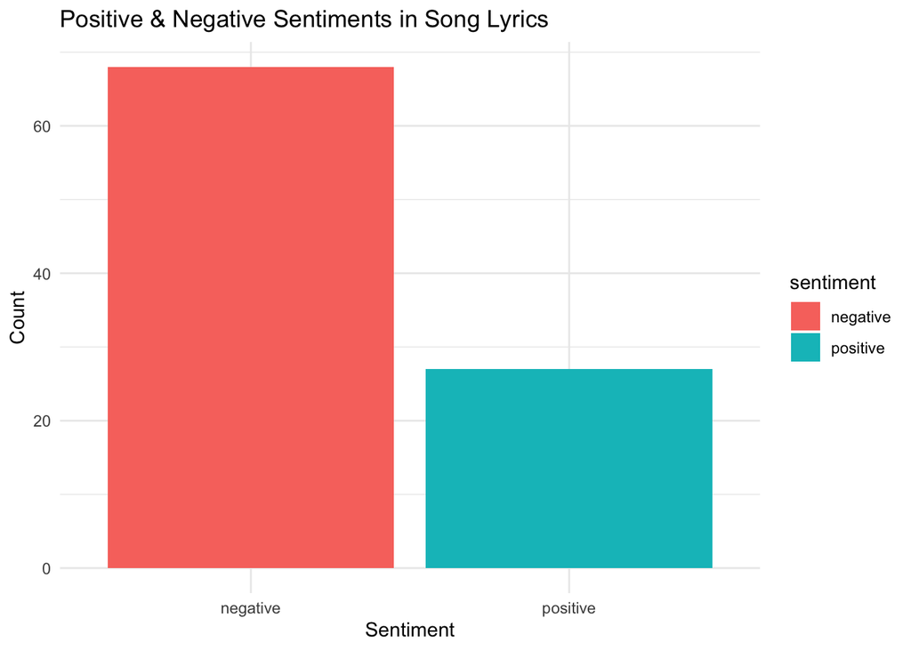

```r
ggplot(sentiment_analysis_bing, aes(x = sentiment, y = n, fill = sentiment)) +
  geom_bar(stat = "identity") +
  theme_minimal() +
  labs(title = "Positive & Negative Sentiments in Song Lyrics", x = "Sentiment", y = "Count")
```

The sentiment analysis of the song lyrics shows that negative words occur significantly more frequently than positive ones. This could indicate that the song lyrics tend to deal with melancholic, critical or gloomy topics.

#### 0.8.2.3 NRC Sentiment Anaylysis

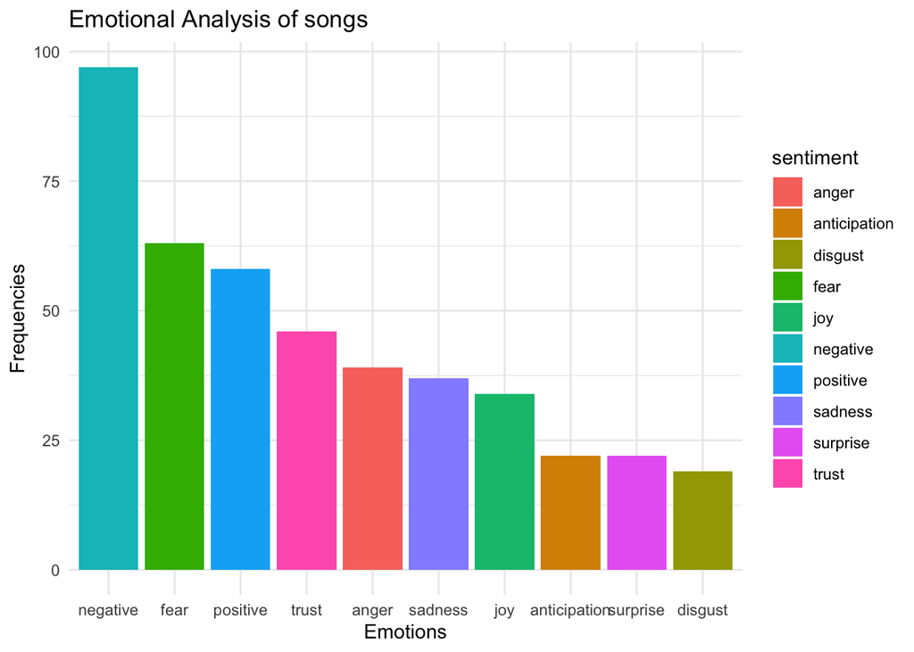

```r
sentiments_nrc <- get_sentiments("nrc")

sentiment_analysis_nrc <- german_lyrics_cleaned %>%
  inner_join(sentiments_nrc, by = "word") %>%
  count(sentiment, sort = TRUE)
ggplot(sentiment_analysis_nrc, aes(x = reorder(sentiment, -n), y = n, fill = sentiment)) +
  geom_bar(stat = "identity") +
  theme_minimal() +
  labs(title = "Emotional Analysis of songs", x = "Emotions", y = "Frequencies")
```

The emotional analysis of the lyrics shows that negative emotions occur most frequently, followed by fear and a moderate number of positive terms. This indicates that the lyrics often have a gloomy or serious atmosphere, but still contain elements of trust and positive emotions.

#### 0.8.2.4 Word Correlations: Male & Female

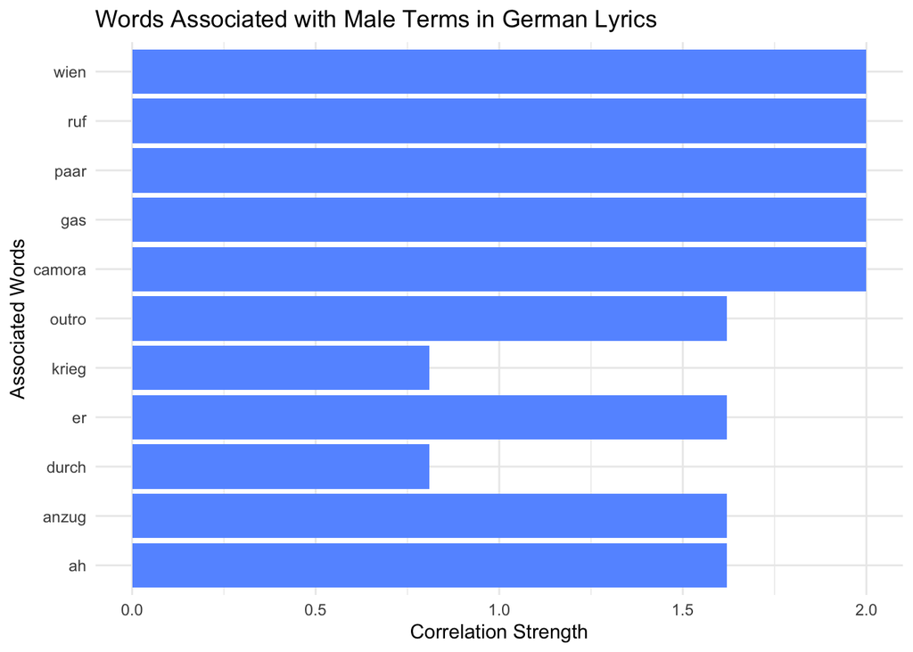

```r
word_correlation <- german_lyrics_cleaned %>%
  unnest_tokens(word, lyrics) %>%
  pairwise_cor(word, track_name, sort = TRUE)

male_terms <- c("digga")
female_terms <- c("frau", "frauen", "frau'n")

male_related_words <- word_correlation %>%
  filter(item1 %in% male_terms | item2 %in% male_terms) %>%
  mutate(
    male_term = ifelse(item1 %in% male_terms, item1, item2),
    other_term = ifelse(item1 %in% male_terms, item2, item1)
  ) %>%
  filter(!(other_term %in% male_terms)) %>%
  filter(correlation > 0.1) %>%
  arrange(desc(correlation)) %>%
  head(20)

female_related_words <- word_correlation %>%
  filter(item1 %in% female_terms) %>%
  mutate(
    female_term = ifelse(item1 %in% female_terms, item1, item2),
    other_term = ifelse(item1 %in% female_terms, item2, item1)
  ) %>%
  filter(!(other_term %in% female_terms)) %>%
  filter(correlation > 0.1) %>%
  arrange(desc(correlation)) %>%
  head(20)

ggplot(male_related_words,
       aes(x = reorder(other_term, correlation), y = correlation)) +
  geom_col(fill = "#6699FF") +
  coord_flip() +
  theme_minimal() +
  labs(
    title = "Words Associated with Male Terms in German Lyrics",
    x = "Associated Words",
    y = "Correlation Strength"
  )
```

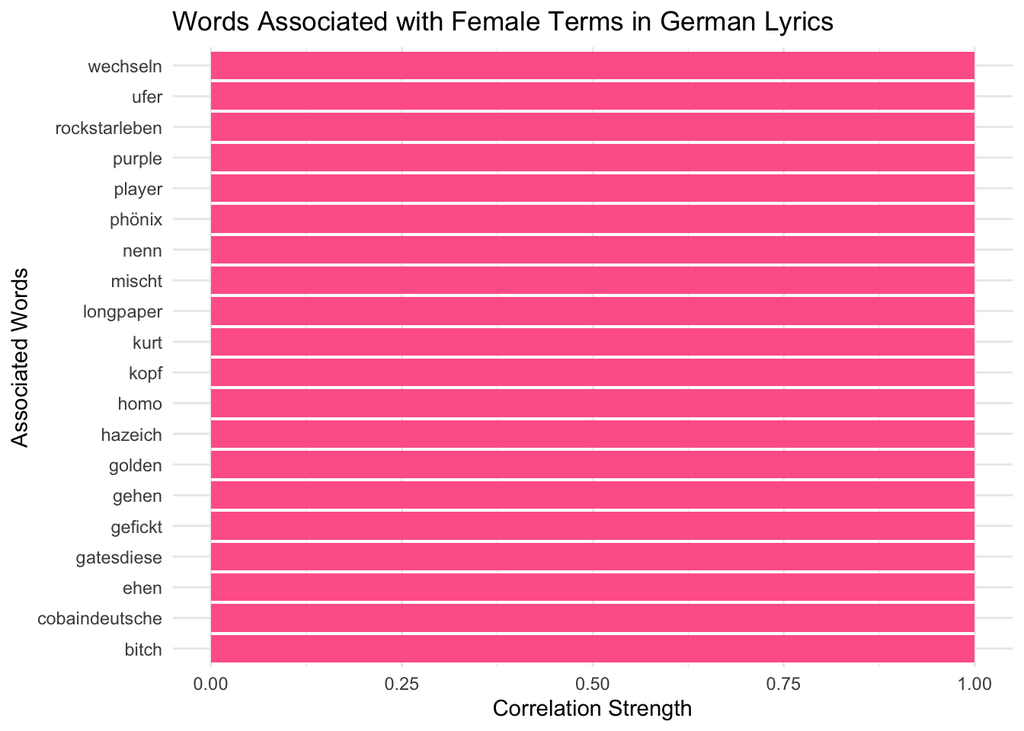

```r
ggplot(female_related_words,
       aes(x = reorder(other_term, correlation), y = correlation)) +
  geom_col(fill = "#FF6699") +
  coord_flip() +
  theme_minimal() +
  labs(
    title = "Words Associated with Female Terms in German Lyrics",
    x = "Associated Words",
    y = "Correlation Strength"
  )
```

The words associated with male terms in German lyrics change each time we run our code, so our analysis may vary.

#### 0.8.2.5 Word Correlations

```r
word_correlation <- german_lyrics_cleaned %>%
  unnest_tokens(word, lyrics) %>%
  pairwise_cor(word, track_name, sort = TRUE)


print(head(word_correlation, 20))
```

```
# A tibble: 20 × 3
   item1    item2      correlation
   <chr>    <chr>            <dbl>
 1 nie      ein'n                1
 2 ein'n    nie                  1
 3 es       was                  1
 4 was      es                   1
 5 du       songtext             1
 6 songtext du                   1
 7 mir      mich                 1
 8 der      mich                 1
 9 damit    kennst               1
10 liebe    kennst               1
11 sitzt    kennstdann           1
12 neben    kennstdann           1
13 benzja   kennstdann           1
14 rauchen  kennstdann           1
15 rakete   kennstdann           1
16 dachweil kennstdann           1
17 kuzengs  kennstdann           1
18 dicka    kennstdann           1
19 lol      kennstdann           1
20 schwöre  kennstdann           1
```

```r
word_correlation
```

```
# A tibble: 3,491,292 × 3
   item1    item2    correlation
   <chr>    <chr>          <dbl>
 1 nie      ein'n              1
 2 ein'n    nie                1
 3 es       was                1
 4 was      es                 1
 5 du       songtext           1
 6 songtext du                 1
 7 mir      mich               1
 8 der      mich               1
 9 damit    kennst             1
10 liebe    kennst             1
# ℹ 3,491,282 more rows
```

```r
mann_correlation <- word_correlation %>%
  filter(item1 == "männer" | item2 == "mann")

print(mann_correlation)
```

```
# A tibble: 1,868 × 3
   item1  item2         correlation
   <chr>  <chr>               <dbl>
 1 männer phönix                  1
 2 männer bitch                   1
 3 männer mischt                  1
 4 männer player                  1
 5 männer longpaper               1
 6 männer purple                  1
 7 männer hazeich                 1
 8 männer rockstarleben           1
 9 männer kopf                    1
10 männer gehen                   1
# ℹ 1,858 more rows
```

```r
frau_correlation <- word_correlation %>%
  filter(item1 == "frauen"| item2 == "frauen")

print(frau_correlation)
```

```
# A tibble: 3,736 × 3
   item1  item2         correlation
   <chr>  <chr>               <dbl>
 1 frauen phönix                  1
 2 frauen bitch                   1
 3 frauen mischt                  1
 4 frauen player                  1
 5 frauen longpaper               1
 6 frauen purple                  1
 7 frauen hazeich                 1
 8 frauen rockstarleben           1
 9 frauen kopf                    1
10 frauen gehen                   1
# ℹ 3,726 more rows
```

### 0.8.3 Turkish Word Frequencies & Sentiment Analysis

#### 0.8.3.1 Bing Sentiment Analysis (Positive/ Negative)

```r
sentiments_bing_tr <- get_sentiments("bing")

sentiment_analysis_bing_tr <- top_artists_tracks_tr_atomic %>%
  unnest_tokens(word, lyrics) %>%
  filter(!word %in% turkish_stops) %>%
  inner_join(sentiments_bing_tr, by = "word") %>%
  count(sentiment, sort = TRUE)

print(sentiment_analysis_bing_tr)
```

```
# A tibble: 2 × 2
  sentiment     n
  <chr>     <int>
1 positive     10
2 negative      5
```

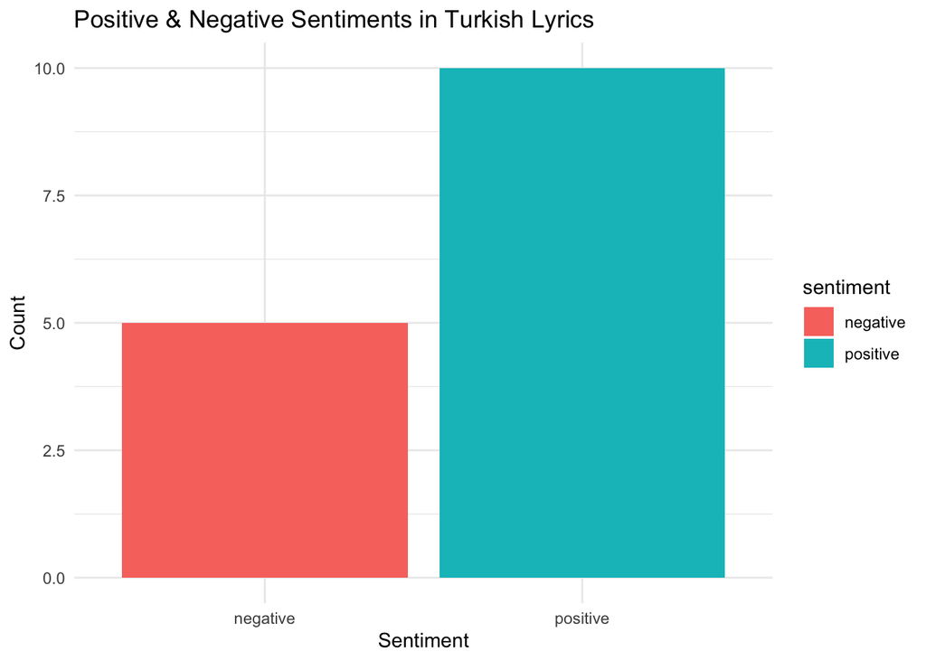

```r
ggplot(sentiment_analysis_bing_tr, aes(x = sentiment, y = n, fill = sentiment)) +
  geom_bar(stat = "identity") +
  theme_minimal() +
  labs(title = "Positive & Negative Sentiments in Turkish Lyrics", x = "Sentiment", y = "Count")
```

#### 0.8.3.2 NRC Sentiment Analysis

```r
sentiments_nrc <- get_sentiments("nrc")

sentiment_analysis_nrc <- top_artists_tracks_tr_atomic %>%
  unnest_tokens(word, lyrics) %>%
  filter(!word %in% turkish_stops) %>%
  inner_join(sentiments_nrc, by = "word") %>%
  count(sentiment, sort = TRUE)
print(sentiment_analysis_nrc)
```

```
# A tibble: 8 × 2
  sentiment        n
  <chr>        <int>
1 positive        13
2 fear             7
3 negative         5
4 anger            4
5 sadness          2
6 trust            2
7 anticipation     1
8 disgust          1
```

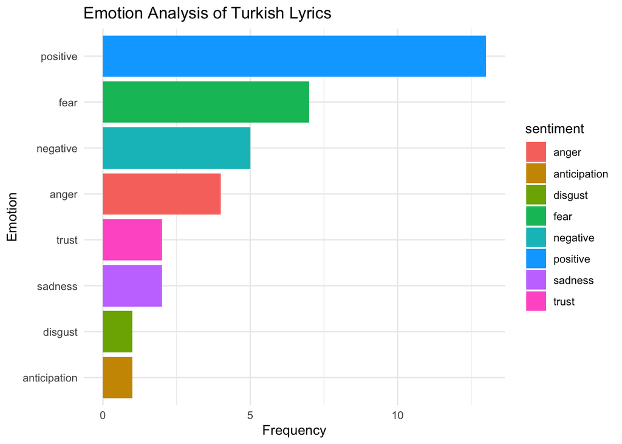

```r
ggplot(sentiment_analysis_nrc, aes(x = reorder(sentiment, n), y = n, fill = sentiment)) +
  geom_bar(stat = "identity") +
  theme_minimal() +
  labs(title = "Emotion Analysis of Turkish Lyrics", x = "Emotion", y = "Frequency") +
  coord_flip()
```

#### 0.8.3.3 Word Correlation Analysis: Male & Female

Turkish rap-hiphop songs like to refer to men in the context of love and material concepts such as money and cars (‘para’ = money, ‘vito’ = famous car model vito). It also stresses the word ‘corleone’ - which is a known name for many of us - that requires no explanation.

It mostly talks about men who like to have fun in parties (see ‘partilerde’ = ‘at parties’, ‘oynuyom’ = ‘I dance’ or ‘I play’, ‘ışklar’ = ‘lights’, and ‘tavlıyon’ = ‘you pull girls’). Funny, right!!

As all the artists from our Turkish playlist are men, it is appropriote to say that male rappers refer to women in melancholic contexts, highlighted by words such as ‘uyuyamamak’ (to not be able to sleep), ‘karmakarışık’ (very complicated), ‘geceler, geceleri, geceleyin’ (at night), ‘fıttırırken’ (as I go crazy), ‘duygularım’ (my emotions), ‘acımasız’ (cruel), ‘bira’ (beer). They also referred to women in the context of fun, although not quite prominently, stressed by ‘eğlence’ (fun).

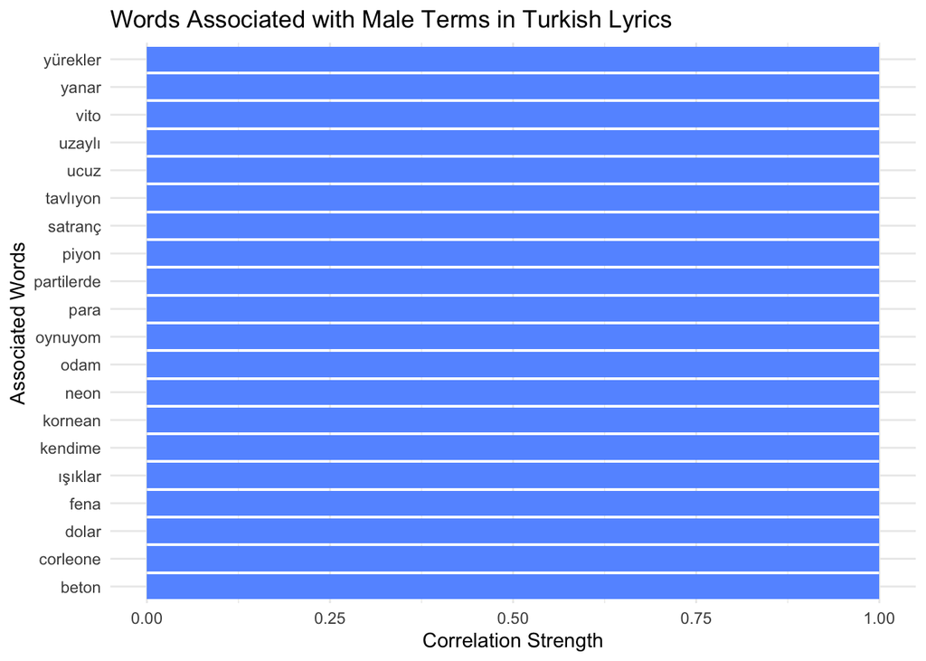

```r
word_correlation_tr <- top_artists_tracks_tr_atomic %>%
  filter(!is.na(track_name)) %>%
  unnest_tokens(word, lyrics) %>%
  filter(!word %in% turkish_stops, nchar(word) > 2) %>%
  pairwise_cor(word, track_name, sort = TRUE)

male_terms_tr <- c("adam", "lavuk", "eleman", "piç", "çocuk", "herif", "dallama")

male_related_words_tr <- word_correlation_tr %>%
  filter(item1 %in% male_terms_tr | item2 %in% male_terms_tr) %>%
  mutate(
    male_term = ifelse(item1 %in% male_terms_tr, item1, item2),
    other_term = ifelse(item1 %in% male_terms_tr, item2, item1)
  ) %>%
  filter(!(other_term %in% male_terms_tr)) %>%
  filter(correlation > 0.1) %>%
  arrange(desc(correlation)) %>%
  head(20)


ggplot(male_related_words_tr,
       aes(x = reorder(other_term, correlation), y = correlation)) +
  geom_col(fill = "#6699FF") +
  coord_flip() +
  theme_minimal() +
  labs(
    title = "Words Associated with Male Terms in Turkish Lyrics",
    x = "Associated Words",
    y = "Correlation Strength"
  )
```

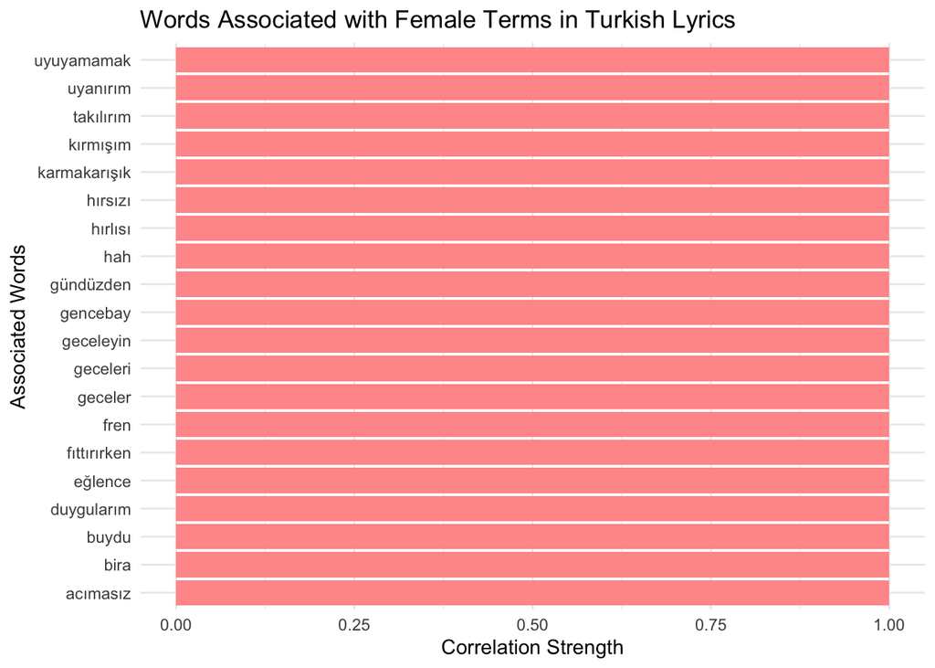

```r
female_terms_tr <- c("kadın", "kadınlar", "o", "kız", "anne", "kızım",
                     "eş", "kız kardeş", "abla", "gelin", "aşk")

female_related_words_tr <- word_correlation_tr %>%
  filter(item1 %in% female_terms_tr | item2 %in% female_terms_tr) %>%
  mutate(
    female_term = ifelse(item1 %in% female_terms_tr, item1, item2),
    other_term = ifelse(item1 %in% female_terms_tr, item2, item1)
  ) %>%
  filter(!(other_term %in% female_terms_tr)) %>%
  filter(correlation > 0.1) %>%
  arrange(desc(correlation)) %>%
  head(20)

ggplot(female_related_words_tr,
       aes(x = reorder(other_term, correlation), y = correlation)) +
  geom_col(fill = "#FF9999") +
  coord_flip() +
  theme_minimal() +
  labs(
    title = "Words Associated with Female Terms in Turkish Lyrics",
    x = "Associated Words",
    y = "Correlation Strength"
  )
```

#### 0.8.3.4 AFINN Sentiment Analysis

```r
sentiments_afinn_tr <- get_sentiments("afinn")

sentiment_analysis_afinn_tr <- top_artists_tracks_tr_atomic %>%
  unnest_tokens(word, lyrics) %>%
  filter(!word %in% turkish_stops) %>%
  inner_join(sentiments_afinn_tr, by = "word") %>%
  summarise(sentiment_score = sum(value, na.rm = TRUE))

print(sentiment_analysis_afinn_tr)
```

```
# A tibble: 1 × 1
  sentiment_score
            <dbl>
1              30
```

### 0.8.4 Spanish Word Frequencies & Sentiment Analysis

#### 0.8.4.1 Bing Sentiment Analysis (Positive/ Negative)

```r
sentiments_bing_es <- get_sentiments("bing")

sentiment_analysis_bing_es <- top_artists_tracks_es_atomic %>%
  unnest_tokens(word, lyrics_es) %>%
  filter(!word %in% all_stopwords) %>%
  inner_join(sentiments_bing_es, by = "word") %>%
  count(sentiment, sort = TRUE)

print(sentiment_analysis_bing_es)
```

```
# A tibble: 2 × 2
  sentiment     n
  <chr>     <int>
1 positive     26
2 negative     25
```

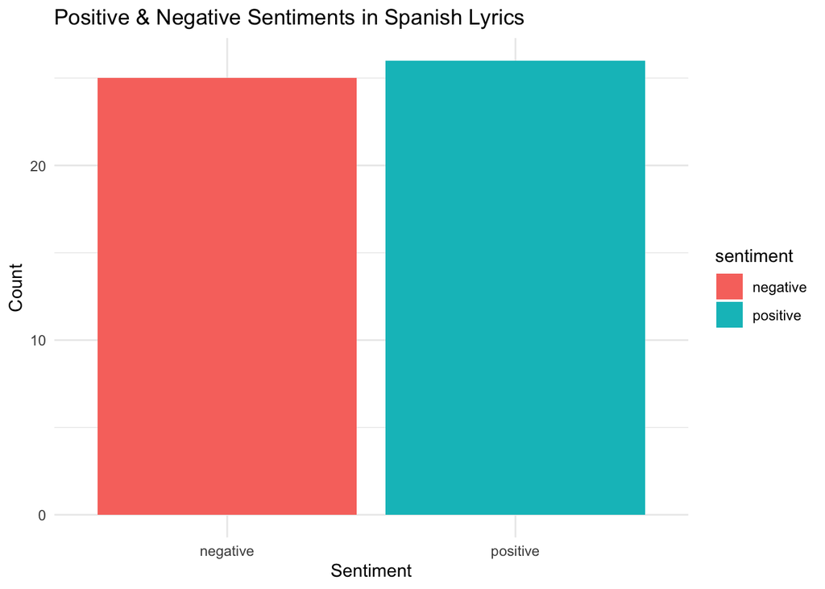

```r
ggplot(sentiment_analysis_bing_es, aes(x = sentiment, y = n, fill = sentiment)) +
  geom_bar(stat = "identity") +
  theme_minimal() +
  labs(title = "Positive & Negative Sentiments in Spanish Lyrics", x = "Sentiment", y = "Count")
```

#### 0.8.4.2 NRC Sentiment Anaylysis

```r
sentiments_nrc_es <- get_sentiments("nrc")

sentiment_analysis_nrc_es <- top_artists_tracks_es_atomic %>%
  unnest_tokens(word, lyrics_es) %>%
  filter(!word %in% all_stopwords) %>%
  inner_join(sentiments_nrc_es, by = "word") %>%
  count(sentiment, sort = TRUE)
print(sentiment_analysis_nrc_es)
```

```
# A tibble: 10 × 2
   sentiment        n
   <chr>        <int>
 1 positive        46
 2 negative        39
 3 anger           28
 4 fear            27
 5 joy             25
 6 sadness         24
 7 disgust         18
 8 anticipation    14
 9 trust           14
10 surprise         1
```

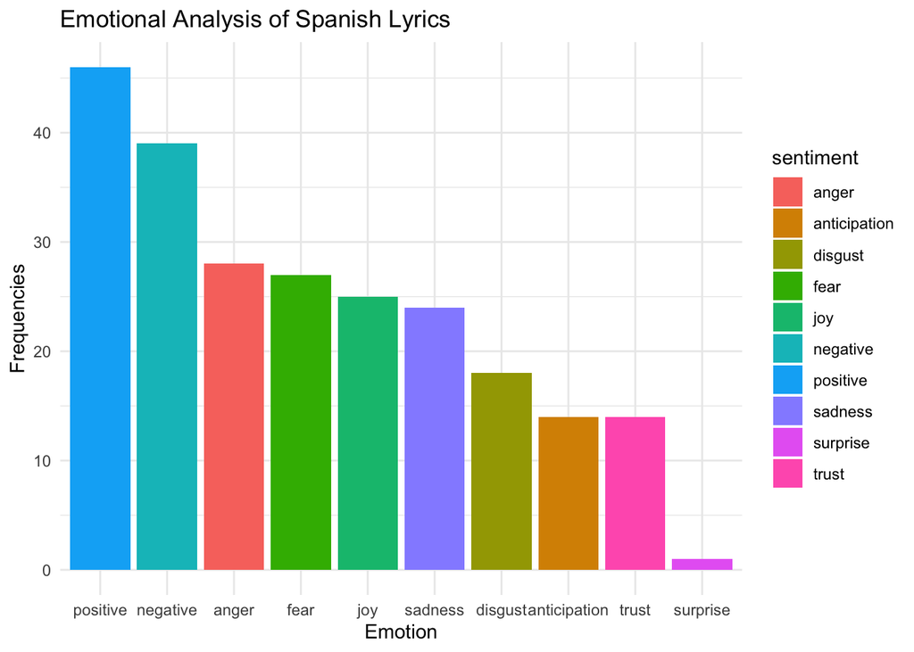

```r
ggplot(sentiment_analysis_nrc_es, aes(x = reorder(sentiment, -n), y = n, fill = sentiment)) +
  geom_bar(stat = "identity") +
  theme_minimal() +
  labs(title = "Emotional Analysis of Spanish Lyrics", x = "Emotion", y = "Frequencies")
```

The emotional analysis of the lyrics reveals that positivity is the most expressed emotion, closely followed by negativity, with fear and joy appearing to a lesser extent. This suggests that the lyrics convey a sense of hopefulness, albeit with a touch of restraint.

#### 0.8.4.3 Word Correlation Analysis: Male & Female

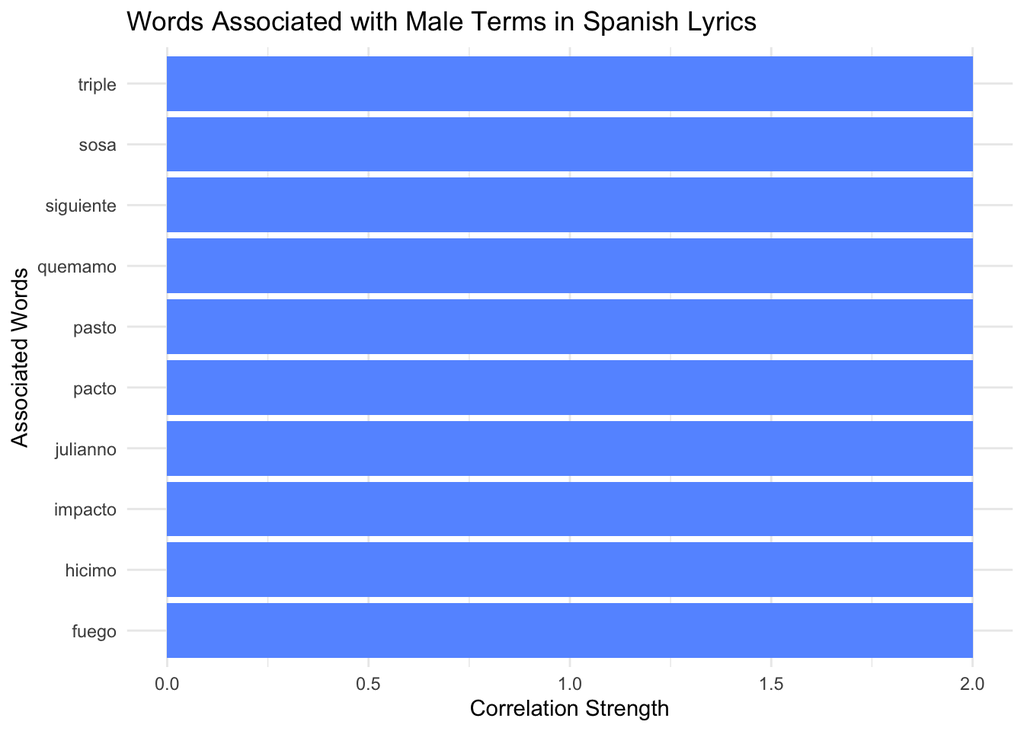

```r
spanish_stopwords <- stopwords::stopwords("es")

word_correlation_es <- top_artists_tracks_es_atomic %>%
  filter(!is.na(track_name_es)) %>%
  unnest_tokens(word, lyrics_es) %>%
  filter(!word %in% spanish_stopwords, nchar(word) > 2) %>%
  pairwise_cor(word, track_name_es, sort = TRUE)


male_terms_es <- c("hombre", "hombres", "tipo", "jefe", "rey", "bro", "pana",
                   "gánster", "calle", "mafioso", "boss",
                   "bandolero", "real g", "maleante", "hermano", "primo", "papi", "compa", "negocio", "lealtad", "respeto")

male_related_words_es <- word_correlation_es %>%
  filter(item1 %in% male_terms_es | item2 %in% male_terms_es) %>%
  mutate(
    male_term = ifelse(item1 %in% male_terms_es, item1, item2),
    other_term = ifelse(item1 %in% male_terms_es, item2, item1)
  ) %>%
  filter(!(other_term %in% male_terms_es)) %>%
  filter(correlation > 0.1) %>%
  arrange(desc(correlation)) %>%
  head(20)


ggplot(male_related_words_es,
       aes(x = reorder(other_term, correlation), y = correlation)) +
  geom_col(fill = "#6699FF") +
  coord_flip() +
  theme_minimal() +
  labs(
    title = "Words Associated with Male Terms in Spanish Lyrics",
    x = "Associated Words",
    y = "Correlation Strength"
  )
```

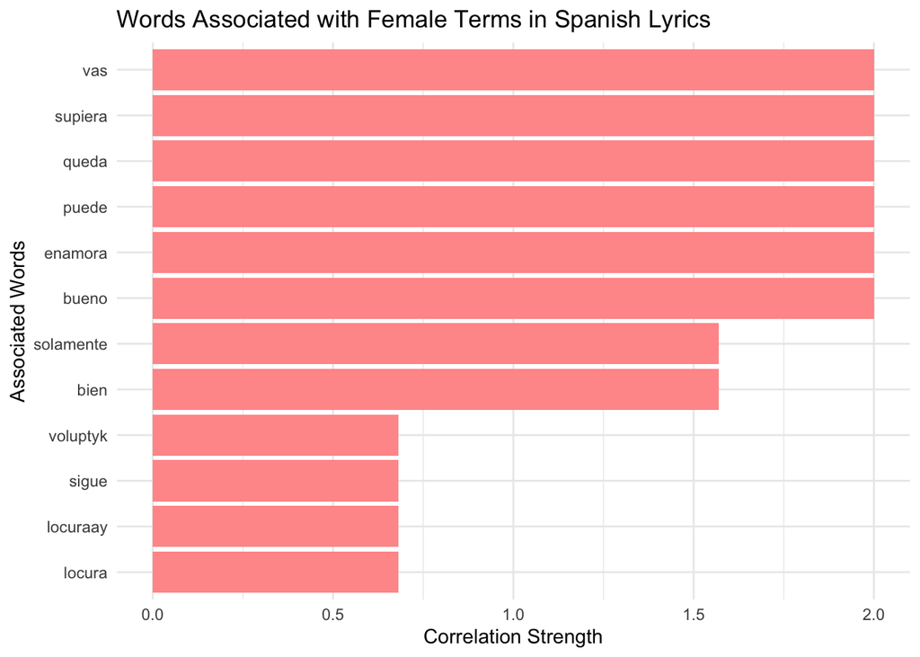

```r
female_terms <- c("mujer", "mujeres", "ella", "chica", "madre", "niña",
                  "señora", "esposa", "novia", "hermana", "hija")

female_related_words_es <- word_correlation_es %>%
  filter(item1 %in% female_terms | item2 %in% female_terms) %>%
 mutate(
    female_term = ifelse(item1 %in% female_terms, item1, item2),
    other_term = ifelse(item1 %in% female_terms, item2, item1)
  ) %>%
  filter(!(other_term %in% female_terms)) %>%
  filter(correlation > 0.1) %>%
  arrange(desc(correlation)) %>%
  head(20)  #

ggplot(female_related_words_es,
       aes(x = reorder(other_term, correlation), y = correlation)) +
  geom_col(fill = "#FF9999") +
  coord_flip() +
  theme_minimal() +
  labs(
    title = "Words Associated with Female Terms in Spanish Lyrics",
    x = "Associated Words",
    y = "Correlation Strength"
  )
```

When analyzing male-associated words, we find terms like *“pacto”* (pact), *“quemamo”* (burning), likely symbolizing success, and *“fuego”* (fire), which conveys greatness. The word *“impacto”* (impact) also appears, suggesting their influence on the genre. Overall, male-associated words are closely tied to themes of success and self-importance.

When analyzing female-associated words, we find terms like *“supiera”* (if you knew), *“queda”* (stay), *“enamora”* (fall in love), and *“locura”* (madness/crazy). These words suggest that female-associated language is more centered around love, emotions, and relationships.

#### 0.8.4.4 AFINN Sentiment Analysis (Numerical Scores)

```r
sentiments_afinn_es <- get_sentiments("afinn")

sentiment_analysis_afinn_es <- top_artists_tracks_es_atomic %>%
  unnest_tokens(word, lyrics_es) %>%
  filter(!word %in% all_stopwords) %>%
  inner_join(sentiments_afinn_es, by = "word") %>%
  summarise(sentiment_score = sum(value, na.rm = TRUE))

print(sentiment_analysis_afinn_es)
```

```
# A tibble: 1 × 1
  sentiment_score
            <dbl>
1               5
```

## 0.9 DE- TR- ES Sentiment Comparison

```r
sentiment_analysis_bing_es <- sentiment_analysis_bing_es %>% mutate(language = "Spanish")
sentiment_analysis_bing_tr <- sentiment_analysis_bing_tr %>% mutate(language = "Turkish")
sentiment_analysis_bing_de <- sentiment_analysis_bing %>% mutate(language = "German")

sentiment_comparison <- bind_rows(sentiment_analysis_bing_es,
                                  sentiment_analysis_bing_tr,
                                  sentiment_analysis_bing_de)

sentiment_analysis_nrc_es <- sentiment_analysis_nrc_es %>% mutate(language = "Spanish")
sentiment_analysis_nrc_tr <- sentiment_analysis_nrc %>% mutate(language = "Turkish")
sentiment_analysis_nrc_de <- sentiment_analysis_nrc %>% mutate(language = "German")

emotion_comparison <- bind_rows(sentiment_analysis_nrc_es,
                                sentiment_analysis_nrc_tr,
                                sentiment_analysis_nrc_de)
```

The below bar plot provides a quick comparison for all three languages on the basis of positive and negative sentiments. Due to considerably greater volume of words in the songs that are present in our list, German tops both sentiments in the count of words that represent each sentiment.

Spanish is second to German in terms of the count of words reflecting both positivity and negativity, however, both sentiments post highly close numbers, offering a balance as explained in the previous sections.

Turkish has the lowest number of words in both sentiments, however, this is due to the relatively lower volume of words across all songs. This also has implications that Turkish rap-hiphop songs are not constructed in sentences with a high number of words, instead, they form shorter sentences and let the vibes do the rest!

It is also possible to say that German rap/hiphop is arguably based on long sentences and maybe even story telling, just like old school versions of the genre. Gür likes this a lot!

Spanish songs, on the other hand, demonstrate an in-between performance regarding the number of words, proposing a modest way.

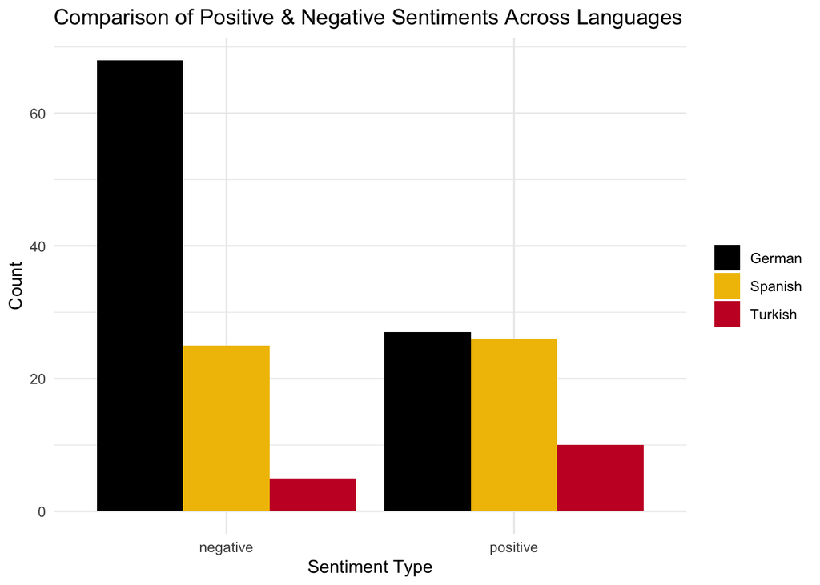

```r
ggplot(sentiment_comparison, aes(x = sentiment, y = n, fill = language)) +
  geom_bar(stat = "identity", position = "dodge") +
  theme_minimal() +
  labs(title = "Comparison of Positive & Negative Sentiments Across Languages",
       x = "Sentiment Type", y = "Count") +
  scale_fill_manual(values = c("Spanish" = "#F1BF00", "Turkish" = "#C8102E", "German" = "black")) +
  theme(legend.title = element_blank())
```

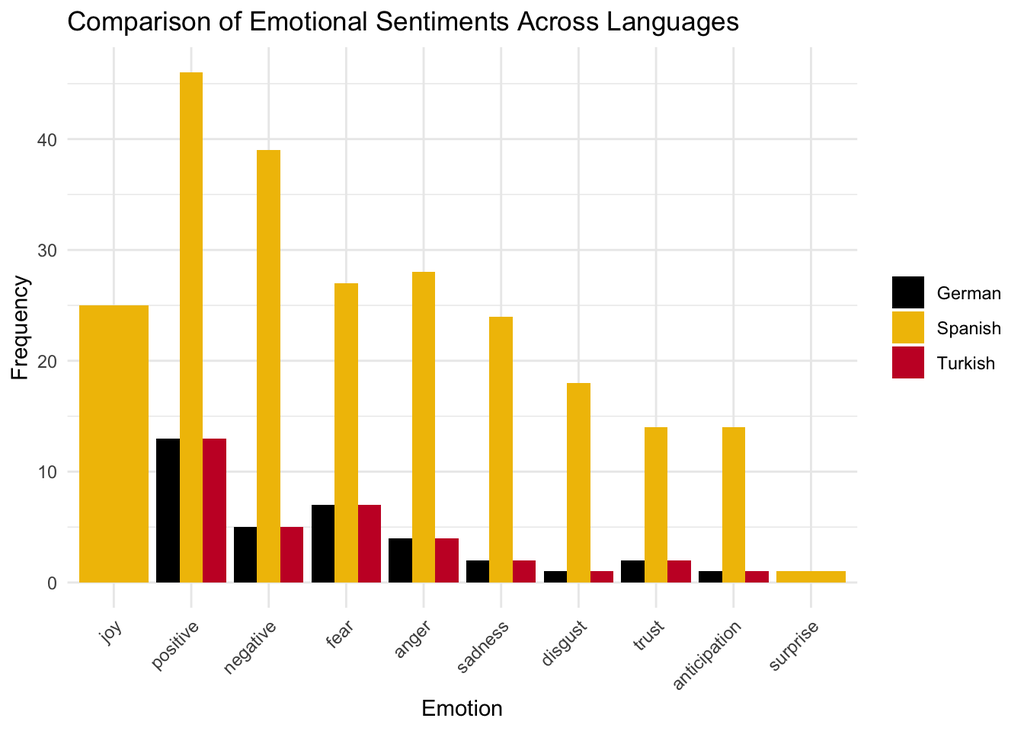

```r
ggplot(emotion_comparison, aes(x = reorder(sentiment, -n), y = n, fill = language)) +
  geom_bar(stat = "identity", position = "dodge") +
  theme_minimal() +
  labs(title = "Comparison of Emotional Sentiments Across Languages",
       x = "Emotion", y = "Frequency") +
  scale_fill_manual(values = c("Spanish" = "#F1BF00", "Turkish" = "#C8102E", "German" = "black")) +
  theme(axis.text.x = element_text(angle = 45, hjust = 1),
        legend.title = element_blank())
```

# 1 Concluson

What started as a quest to uncover gender-related violent language in hip-hop and rap lyrics across German, Turkish, and Spanish music quickly turned into something bigger: an exploration of lyrical emotions, gendered language, and the unique vibes of each culture’s rap scene. Turns out, rappers across these languages aren’t dropping violent bars about gender all that much—but they do have a lot to say about success, struggle, and emotions.

What We Found:

Sentiment Showdown: German rap goes all-in, packing both the most positive and negative words— think dramatic storytelling with serious emotional weight. Spanish lyrics keep things balanced, serving a mix of love, heartbreak, and confidence. Turkish rap keeps it short but powerful, leaning into melancholic vibes, nightlife, and raw emotion.

Bottom line? Across the board, men are rapping about status, power, and nightlife, while women in lyrics are more tied to love, emotions, and personal struggles.

The Big Picture: Across the board, men rap about status, power, and nightlife, while women in lyrics are more connected to love, emotions, and personal struggles. German rap brings the lyrical fire with intense storytelling, Turkish rap packs an emotional punch, balancing party life with deep personal struggles, and Spanish rap smooths it all out with love and self-reflection. While cultural differences shape the way emotions and success are expressed, hip-hop in every language remains a universal mix of ambition, struggle, and storytelling.